# DNA and collagen preservation modelling

Andi Wilson and Deon de Jager

2025-12-21

# 0. Experiment Details

**Aim:**

- To determine whether age of specimen affects the preservation of aDNA
- To determine whether age of specimen affects the preservation of collagen
- To determine whether DNA and collagen preservation are correlated
- To determine whether age of specimen affects read length

**Factors to consider:**

- noMicro_endoPropxTarget: This is the endogenous DNA proportion where microbe-like and mitochondrial-like regions have been masked.
- latest_chrono_age: This is the estimated age of the specimen.
- Site_short: The fossil sites, in shorthand.
- Taxon_plots_common: The assigned taxon for plotting and modelling purposes.
- material_group: Tooth or Bone.
- species_identifiable: Yes or No.
- noMicro_meanLengthxTarget: The mean read length of endogenous reads (only relevant for those where species_identifiable == “Yes”).
- Coll_Yield_perc: The collagen yield as a percentage. Only relevant for Phase 1 specimens (StudyPhase == “Phase1”).

**Analyses performed:**

- **Analysis 1:** Endogenous DNA content vs age
- **Analysis 2:** Collagen yield vs age
- **Analysis 3:** Endogenous DNA content vs collagen yield
- **Analysis 4:** Read length vs age
  - First analysis: Including all sites
  - Second analysis: Including only NBC

#### Load libraries and set working directory

```r
library(ggplot2)
library(tidyverse)
library(rstatix)
library(lme4)
library(MASS)

#setwd("")
```

# 1. ENDOGENOUS DNA CONTENT vs AGE

#### Load data

```r
Data <- read_csv("Table S3 - paleomix nuclear & collagen.csv")

#Log transform the endogenous content column
Data$log_endo <- log(Data$noMicro_endoPropxTarget)
```

#### Create plot of age vs endogenous content

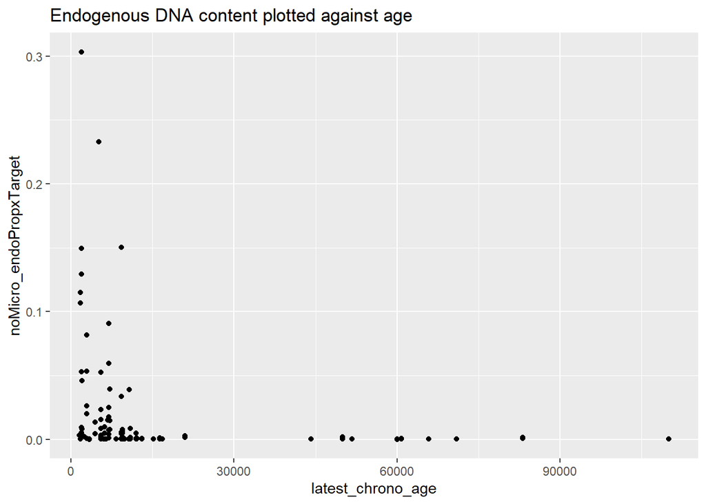

```r
Data %>%
  ggplot(aes(x = latest_chrono_age, y = noMicro_endoPropxTarget)) +
  geom_jitter() +
  labs(title = "Endogenous DNA content plotted against age")
```

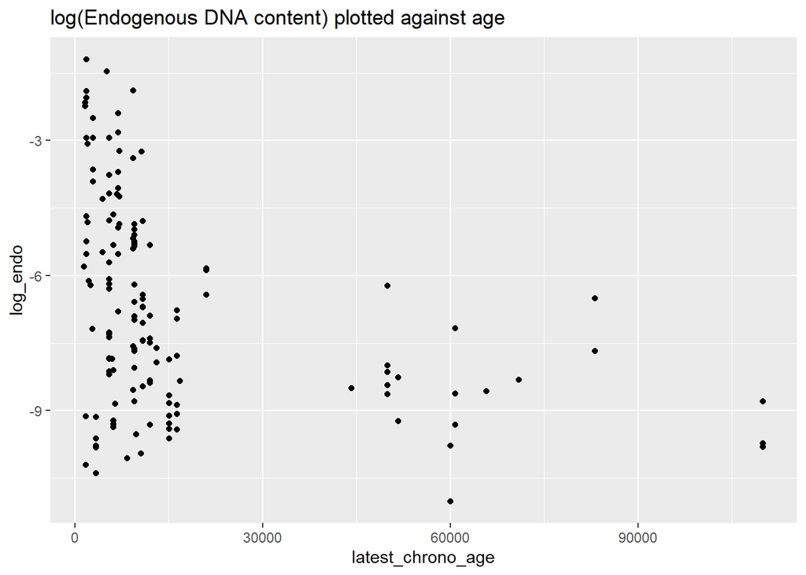

```r
Data %>%
  ggplot(aes(x = latest_chrono_age, y = log_endo)) +
  geom_jitter() +
  labs(title = "log(Endogenous DNA content) plotted against age")
```

#### Histograms

#### Figure out distribution of the data, based on endogenous content

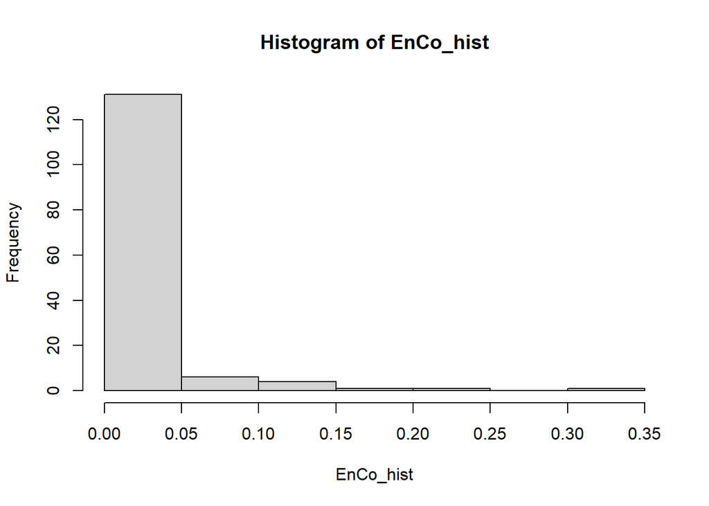

```r
#Filter based just on the endogenous content
EnCo_hist <- Data$noMicro_endoPropxTarget
LogEnCo_hist <- Data$log_endo

#Generate the  histogram
hist(EnCo_hist)
```

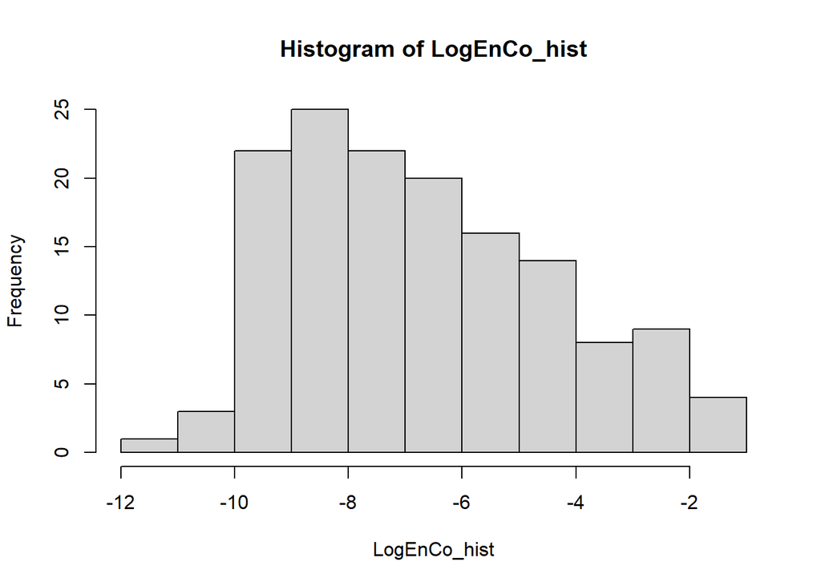

```r
hist(LogEnCo_hist)
```

**Note:** The log transformed data looks more or less normally distributed, so test out linear models based on gaussian (=normal) distributions

#### Testing various models

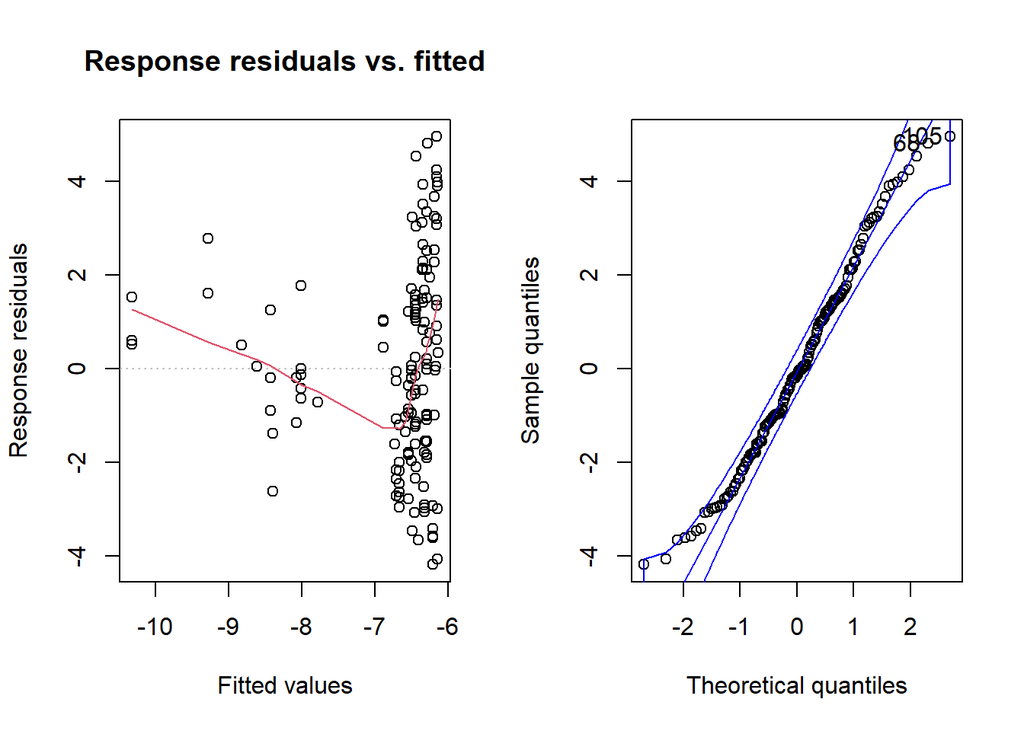

```r
#Use linear models for all, but test for the various potential factors
## Set sum-to-zero contrasts to compare each site to the overall average, instead of a reference site,
## which by default is the first site alphabetically (BNK1). Will also apply to taxon and material group.
#Model only considering the effect of age on endogenous content
LM <- lm(log_endo ~ latest_chrono_age, data = Data)
RVAideMemoire::plotresid(LM)
```

```r
summary(LM)
```

```
##
## Call:
## lm(formula = log_endo ~ latest_chrono_age, data = Data)
##
## Residuals:
##     Min      1Q  Median      3Q     Max
## -4.1836 -1.5782 -0.1401  1.4680  4.9561
##
## Coefficients:
##                     Estimate Std. Error t value Pr(>|t|)
## (Intercept)       -6.077e+00  2.216e-01 -27.427  < 2e-16 ***
## latest_chrono_age -3.866e-05  8.065e-06  -4.793  4.1e-06 ***
## ---
## Signif. codes:  0 '***' 0.001 '**' 0.01 '*' 0.05 '.' 0.1 ' ' 1
##
## Residual standard error: 2.136 on 142 degrees of freedom
##   (28 observations deleted due to missingness)
## Multiple R-squared:  0.1392, Adjusted R-squared:  0.1332
## F-statistic: 22.97 on 1 and 142 DF,  p-value: 4.101e-06
```

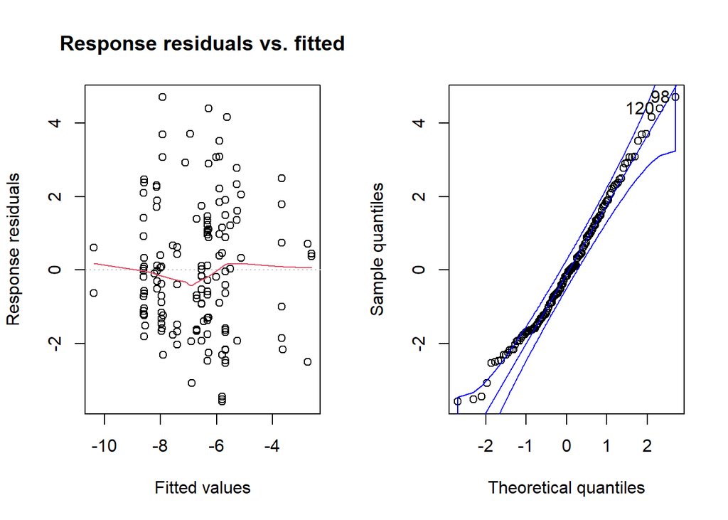

```r
#Model considering the effect of age and its interaction with site on endogenous content
## Set levels, so that all sites are compared to NBC (largest sample size). See also options("contrasts")
Data$Site_short <- factor(Data$Site_short,
                         levels = c("NBC", "DK1", "EBC", "KRM", "BPA", "BNK1"))
LM_SS <- lm(log_endo ~ latest_chrono_age * Site_short, data = Data)
RVAideMemoire::plotresid(LM_SS)
```

```r
summary(LM_SS)
```

```
##
## Call:
## lm(formula = log_endo ~ latest_chrono_age * Site_short, data = Data)
##
## Residuals:
##     Min      1Q  Median      3Q     Max
## -3.5726 -1.3725 -0.1603  1.1677  4.6951
##
## Coefficients:
##                                    Estimate Std. Error t value Pr(>|t|)
## (Intercept)                      -4.809e+00  4.706e-01 -10.220  < 2e-16 ***
## latest_chrono_age                -1.589e-04  4.816e-05  -3.299 0.001249 **
## Site_shortDK1                     1.343e+00  9.010e-01   1.490 0.138592
## Site_shortEBC                     2.740e+00  8.969e+00   0.305 0.760497
## Site_shortKRM                    -3.770e+00  8.135e-01  -4.634 8.48e-06 ***
## Site_shortBPA                    -3.087e+00  7.865e-01  -3.925 0.000139 ***
## Site_shortBNK1                    3.730e+00  1.329e+00   2.806 0.005777 **
## latest_chrono_age:Site_shortDK1   4.352e-05  5.453e-05   0.798 0.426265
## latest_chrono_age:Site_shortEBC  -2.962e-04  7.504e-04  -0.395 0.693727
## latest_chrono_age:Site_shortKRM   1.585e-04  4.934e-05   3.213 0.001649 **
## latest_chrono_age:Site_shortBPA   1.543e-04  5.218e-05   2.956 0.003691 **
## latest_chrono_age:Site_shortBNK1 -7.363e-04  2.454e-04  -3.001 0.003219 **
## ---
## Signif. codes:  0 '***' 0.001 '**' 0.01 '*' 0.05 '.' 0.1 ' ' 1
##
## Residual standard error: 1.823 on 132 degrees of freedom
##   (28 observations deleted due to missingness)
## Multiple R-squared:  0.4175, Adjusted R-squared:  0.3689
## F-statistic:   8.6 on 11 and 132 DF,  p-value: 2.479e-11
```

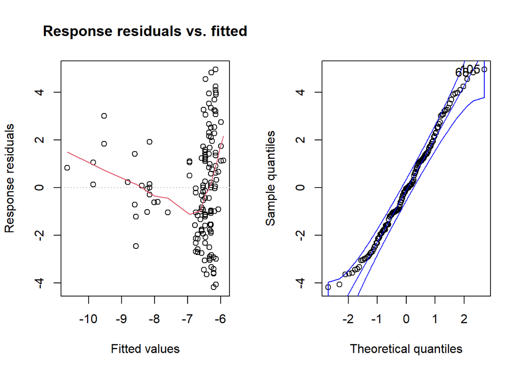

```r
#Model considering the effect of age and its interaction with material group on endogenous content
## Set levels, so that tooth is the reference. See also options("contrasts")
Data$material_group <- factor(Data$material_group,
                              levels = c("Tooth", "Bone"))
LM_MG <- lm(log_endo ~ latest_chrono_age * material_group, data = Data)
RVAideMemoire::plotresid(LM_MG)
```

```r
summary(LM_MG)
```

```
##
## Call:
## lm(formula = log_endo ~ latest_chrono_age * material_group, data = Data)
##
## Residuals:
##     Min      1Q  Median      3Q     Max
## -4.1764 -1.5573 -0.0352  1.3873  4.9589
##
## Coefficients:
##                                        Estimate Std. Error t value Pr(>|t|)
## (Intercept)                          -6.074e+00  2.366e-01 -25.670  < 2e-16 ***
## latest_chrono_age                    -4.157e-05  1.006e-05  -4.130  6.2e-05 ***
## material_groupBone                    3.566e-01  8.624e-01   0.413    0.680
## latest_chrono_age:material_groupBone  3.866e-06  1.865e-05   0.207    0.836
## ---
## Signif. codes:  0 '***' 0.001 '**' 0.01 '*' 0.05 '.' 0.1 ' ' 1
##
## Residual standard error: 2.147 on 140 degrees of freedom
##   (28 observations deleted due to missingness)
## Multiple R-squared:  0.1427, Adjusted R-squared:  0.1244
## F-statistic: 7.769 on 3 and 140 DF,  p-value: 7.77e-05
```

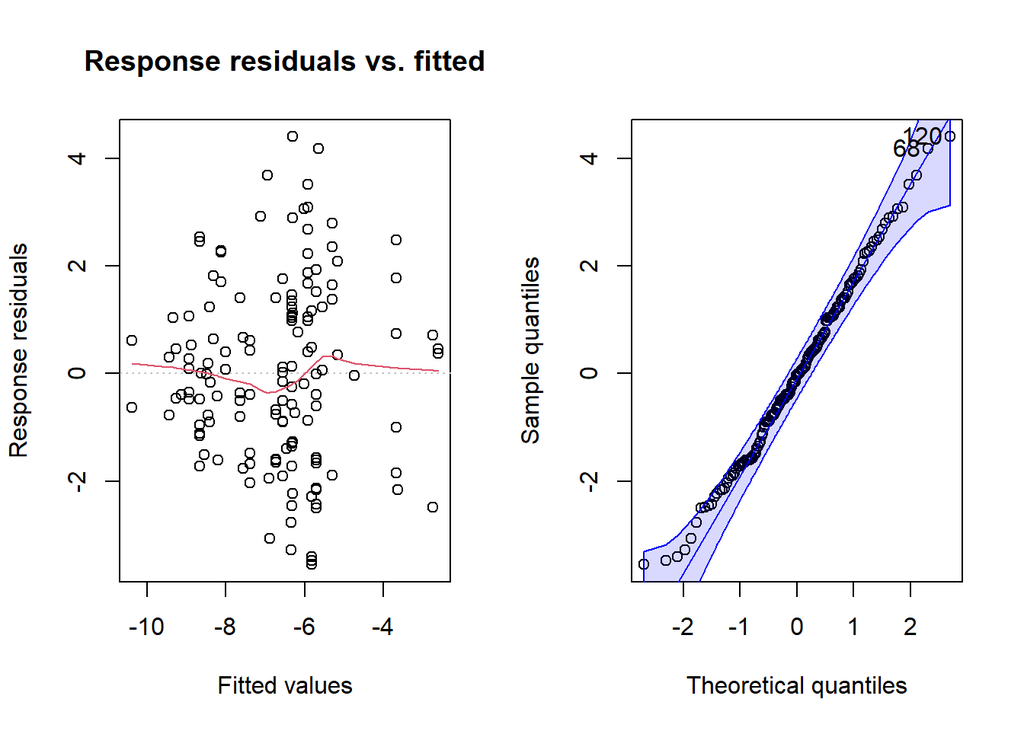

```r
#Model considering the effect of age and its interaction with site and material group on endogenous content
LM_SS_MG <- lm(log_endo ~ latest_chrono_age * Site_short * material_group, data = Data)
RVAideMemoire::plotresid(LM_SS_MG)
```

```r
summary(LM_SS_MG)
```

```
##
## Call:
## lm(formula = log_endo ~ latest_chrono_age * Site_short * material_group,
##     data = Data)
##
## Residuals:
##     Min      1Q  Median      3Q     Max
## -3.5526 -1.3070 -0.0255  1.1371  4.4054
##
## Coefficients: (6 not defined because of singularities)
##                                                       Estimate Std. Error
## (Intercept)                                         -4.843e+00  4.673e-01
## latest_chrono_age                                   -1.567e-04  4.757e-05
## Site_shortDK1                                        1.376e+00  8.886e-01
## Site_shortEBC                                        2.773e+00  8.823e+00
## Site_shortKRM                                       -3.836e+00  8.194e-01
## Site_shortBPA                                       -4.657e+00  9.357e-01
## Site_shortBNK1                                       3.763e+00  1.309e+00
## material_groupBone                                   2.141e+00  4.650e+00
## latest_chrono_age:Site_shortDK1                      4.136e-05  5.382e-05
## latest_chrono_age:Site_shortEBC                     -2.983e-04  7.382e-04
## latest_chrono_age:Site_shortKRM                      1.610e-04  4.924e-05
## latest_chrono_age:Site_shortBPA                      1.940e-04  5.481e-05
## latest_chrono_age:Site_shortBNK1                    -7.385e-04  2.414e-04
## latest_chrono_age:material_groupBone                -2.168e-04  5.595e-04
## Site_shortDK1:material_groupBone                            NA         NA
## Site_shortEBC:material_groupBone                            NA         NA
## Site_shortKRM:material_groupBone                    -1.293e+00  6.372e+00
## Site_shortBPA:material_groupBone                     1.824e+00  4.821e+00
## Site_shortBNK1:material_groupBone                           NA         NA
## latest_chrono_age:Site_shortDK1:material_groupBone          NA         NA
## latest_chrono_age:Site_shortEBC:material_groupBone          NA         NA
## latest_chrono_age:Site_shortKRM:material_groupBone   1.995e-04  5.615e-04
## latest_chrono_age:Site_shortBPA:material_groupBone   1.259e-04  5.609e-04
## latest_chrono_age:Site_shortBNK1:material_groupBone         NA         NA
##                                                     t value Pr(>|t|)
## (Intercept)                                         -10.362  < 2e-16 ***
## latest_chrono_age                                    -3.294 0.001283 **
## Site_shortDK1                                         1.548 0.124035
## Site_shortEBC                                         0.314 0.753809
```

[output cut: 12 more lines]

```
## Site_shortKRM:material_groupBone                     -0.203 0.839503
## Site_shortBPA:material_groupBone                      0.378 0.705894
## Site_shortBNK1:material_groupBone                        NA       NA
## latest_chrono_age:Site_shortDK1:material_groupBone       NA       NA
## latest_chrono_age:Site_shortEBC:material_groupBone       NA       NA
## latest_chrono_age:Site_shortKRM:material_groupBone    0.355 0.722882
## latest_chrono_age:Site_shortBPA:material_groupBone    0.224 0.822798
## latest_chrono_age:Site_shortBNK1:material_groupBone      NA       NA
## ---
## Signif. codes:  0 '***' 0.001 '**' 0.01 '*' 0.05 '.' 0.1 ' ' 1
##
## Residual standard error: 1.793 on 126 degrees of freedom
##   (28 observations deleted due to missingness)
## Multiple R-squared:  0.462,  Adjusted R-squared:  0.3894
## F-statistic: 6.364 on 17 and 126 DF,  p-value: 1.404e-10
```

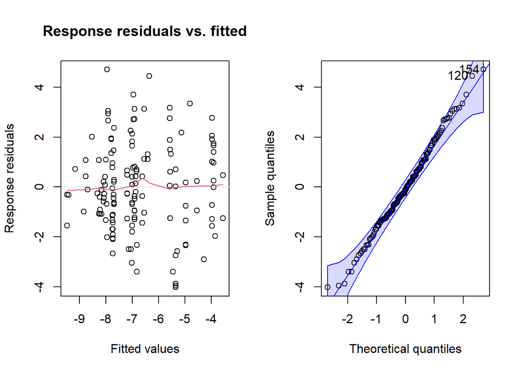

```r
#Model considering the effect of age and its interaction with the taxon on endogenous content
## Set levels, so that all species are compared to Cape buffalo (largest sample size). See also options("contrasts")
Data$Taxon_plots_common <- factor(Data$Taxon_plots_common,
                         levels = c("Cape buffalo", "Cape grysbok", "Common eland", "Grey rhebok", "Long-horned buffalo", "Reedbuck"))
LM_TP <- lm(log_endo ~ latest_chrono_age * Taxon_plots_common, data = Data)
RVAideMemoire::plotresid(LM_TP)
```

```r
summary(LM_TP)
```

```
##
## Call:
## lm(formula = log_endo ~ latest_chrono_age * Taxon_plots_common,
##     data = Data)
##
## Residuals:
##     Min      1Q  Median      3Q     Max
## -4.0177 -1.2323 -0.1093  1.1007  4.7056
##
## Coefficients:
##                                                           Estimate Std. Error
## (Intercept)                                             -3.359e+00  5.830e-01
## latest_chrono_age                                       -3.210e-04  7.638e-05
## Taxon_plots_commonCape grysbok                           6.444e-01  1.031e+00
## Taxon_plots_commonCommon eland                          -4.262e+00  8.194e-01
## Taxon_plots_commonGrey rhebok                           -3.413e+00  7.138e-01
## Taxon_plots_commonLong-horned buffalo                   -4.190e+00  8.182e-01
## Taxon_plots_commonReedbuck                              -3.520e+00  1.047e+00
## latest_chrono_age:Taxon_plots_commonCape grysbok        -8.963e-05  1.382e-04
## latest_chrono_age:Taxon_plots_commonCommon eland         2.903e-04  7.994e-05
## latest_chrono_age:Taxon_plots_commonGrey rhebok          2.971e-04  7.755e-05
## latest_chrono_age:Taxon_plots_commonLong-horned buffalo  3.094e-04  7.765e-05
## latest_chrono_age:Taxon_plots_commonReedbuck             3.045e-04  7.834e-05
##                                                         t value Pr(>|t|)
## (Intercept)                                              -5.762 5.58e-08 ***
## latest_chrono_age                                        -4.203 4.83e-05 ***
## Taxon_plots_commonCape grysbok                            0.625 0.532843
## Taxon_plots_commonCommon eland                           -5.201 7.37e-07 ***
## Taxon_plots_commonGrey rhebok                            -4.782 4.57e-06 ***
## Taxon_plots_commonLong-horned buffalo                    -5.121 1.05e-06 ***
## Taxon_plots_commonReedbuck                               -3.363 0.001010 **
## latest_chrono_age:Taxon_plots_commonCape grysbok         -0.648 0.517790
## latest_chrono_age:Taxon_plots_commonCommon eland          3.631 0.000402 ***
## latest_chrono_age:Taxon_plots_commonGrey rhebok           3.831 0.000197 ***
## latest_chrono_age:Taxon_plots_commonLong-horned buffalo   3.984 0.000111 ***
## latest_chrono_age:Taxon_plots_commonReedbuck              3.888 0.000160 ***
## ---
## Signif. codes:  0 '***' 0.001 '**' 0.01 '*' 0.05 '.' 0.1 ' ' 1
##
## Residual standard error: 1.833 on 132 degrees of freedom
##   (28 observations deleted due to missingness)
## Multiple R-squared:  0.4111, Adjusted R-squared:  0.3621
## F-statistic: 8.379 on 11 and 132 DF,  p-value: 4.728e-11
```

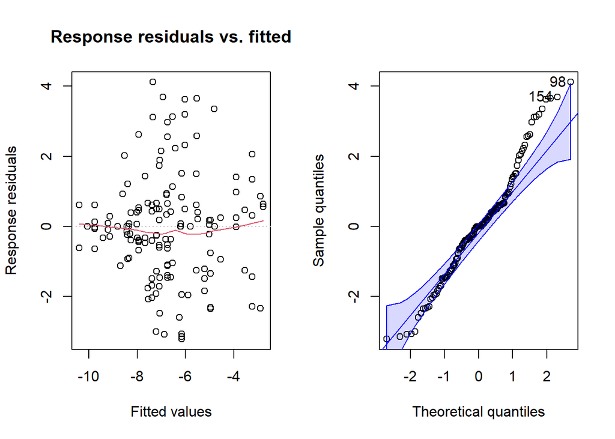

```r
#Model considering the effect of age and its interaction with site and taxon on endogenous content
LM_SS_TP <- lm(log_endo ~ latest_chrono_age * Site_short * Taxon_plots_common, data = Data)
RVAideMemoire::plotresid(LM_SS_TP)
```

```r
summary(LM_SS_TP)
```

```
##
## Call:
## lm(formula = log_endo ~ latest_chrono_age * Site_short * Taxon_plots_common,
##     data = Data)
##
## Residuals:
##     Min      1Q  Median      3Q     Max
## -3.2091 -0.9621  0.0000  0.6223  4.1162
##
## Coefficients: (38 not defined because of singularities)
##                                                                          Estimate
## (Intercept)                                                            -7.392e+00
## latest_chrono_age                                                       1.990e-04
## Site_shortDK1                                                          -8.616e+00
## Site_shortEBC                                                           7.856e-02
## Site_shortKRM                                                           5.464e+01
## Site_shortBPA                                                          -9.325e+00
## Site_shortBNK1                                                          5.833e+00
## Taxon_plots_commonCape grysbok                                          4.677e+00
## Taxon_plots_commonCommon eland                                          5.244e+00
## Taxon_plots_commonGrey rhebok                                           1.124e+00
## Taxon_plots_commonLong-horned buffalo                                  -2.109e+00
## Taxon_plots_commonReedbuck                                              7.406e+00
## latest_chrono_age:Site_shortDK1                                         6.606e-03
## latest_chrono_age:Site_shortEBC                                        -1.521e-04
## latest_chrono_age:Site_shortKRM                                        -1.357e-04
## latest_chrono_age:Site_shortBPA                                         2.980e-04
## latest_chrono_age:Site_shortBNK1                                       -9.211e-04
## latest_chrono_age:Taxon_plots_commonCape grysbok                       -6.097e-04
## latest_chrono_age:Taxon_plots_commonCommon eland                       -5.019e-04
## latest_chrono_age:Taxon_plots_commonGrey rhebok                        -2.855e-04
## latest_chrono_age:Taxon_plots_commonLong-horned buffalo                -6.941e-05
## latest_chrono_age:Taxon_plots_commonReedbuck                           -6.402e-04
## Site_shortDK1:Taxon_plots_commonCape grysbok                                   NA
## Site_shortEBC:Taxon_plots_commonCape grysbok                                   NA
## Site_shortKRM:Taxon_plots_commonCape grysbok                                   NA
## Site_shortBPA:Taxon_plots_commonCape grysbok                                   NA
## Site_shortBNK1:Taxon_plots_commonCape grysbok                                  NA
## Site_shortDK1:Taxon_plots_commonCommon eland                           -3.778e+02
## Site_shortEBC:Taxon_plots_commonCommon eland                                   NA
```

[output cut: 327 more lines]

```
## latest_chrono_age:Site_shortKRM:Taxon_plots_commonLong-horned buffalo
## latest_chrono_age:Site_shortBPA:Taxon_plots_commonLong-horned buffalo
## latest_chrono_age:Site_shortBNK1:Taxon_plots_commonLong-horned buffalo
## latest_chrono_age:Site_shortDK1:Taxon_plots_commonReedbuck
## latest_chrono_age:Site_shortEBC:Taxon_plots_commonReedbuck
## latest_chrono_age:Site_shortKRM:Taxon_plots_commonReedbuck
## latest_chrono_age:Site_shortBPA:Taxon_plots_commonReedbuck
## latest_chrono_age:Site_shortBNK1:Taxon_plots_commonReedbuck
## ---
## Signif. codes:  0 '***' 0.001 '**' 0.01 '*' 0.05 '.' 0.1 ' ' 1
##
## Residual standard error: 1.734 on 110 degrees of freedom
##   (28 observations deleted due to missingness)
## Multiple R-squared:  0.5607, Adjusted R-squared:  0.4289
## F-statistic: 4.255 on 33 and 110 DF,  p-value: 5.56e-09
```

```r
#Calculate the AIC/AIcc values for each model (AICc required for transformed response variable, as in our case)
AIC(LM, LM_SS, LM_MG, LM_SS_MG, LM_TP, LM_SS_TP)
```

```
##          df      AIC
## LM        3 631.2439
## LM_SS    13 595.0216
## LM_MG     5 634.6596
## LM_SS_MG 19 595.5821
## LM_TP    13 596.5746
## LM_SS_TP 35 598.3831
```

```r
purrr::map_dbl(list(LM = LM, LM_SS = LM_SS, LM_MG = LM_MG, LM_SS_MG = LM_SS_MG, LM_TP = LM_TP, LM_SS_TP = LM_SS_TP),
  performance::performance_aicc)
```

```
##       LM    LM_SS    LM_MG LM_SS_MG    LM_TP LM_SS_TP
## 631.4153 597.8216 635.0943 601.7111 599.3746 621.7164
```

**Note:** Both LM_SS (site) and LM_TP (taxon) seem to fit pretty well and their AICc values are the lowest.

1. Independence (horizontal red line on left handside graph) looks ok
2. homoscedasticity (spread of data above and below 0 on left handside graph) looks good
3. and normality (data points inside blue region on right handside graph) looks good.

Will do remaining analyses on both models, but it’s likely that **LM_SS** (site) is more relevant to DNA preservation than **LM_TP** (taxon).

```r
#Linear model with Site included

#ANOVA
car::Anova(LM_SS, type = "II")
```

```
## Anova Table (Type II tests)
##
## Response: log_endo
##                              Sum Sq  Df F value    Pr(>F)
## latest_chrono_age             19.11   1  5.7526 0.0178629 *
## Site_short                    77.46   5  4.6632 0.0005942 ***
## latest_chrono_age:Site_short 132.00   5  7.9459 1.426e-06 ***
## Residuals                    438.55 132
## ---
## Signif. codes:  0 '***' 0.001 '**' 0.01 '*' 0.05 '.' 0.1 ' ' 1
```

```r
#Linear model with Taxon included

#ANOVA
car::Anova(LM_TP, type = "II")
```

```
## Anova Table (Type II tests)
##
## Response: log_endo
##                                      Sum Sq  Df F value    Pr(>F)
## latest_chrono_age                     31.67   1  9.4308 0.0025915 **
## Taxon_plots_common                   112.55   5  6.7029 1.349e-05 ***
## latest_chrono_age:Taxon_plots_common  92.15   5  5.4878 0.0001271 ***
## Residuals                            443.31 132
## ---
## Signif. codes:  0 '***' 0.001 '**' 0.01 '*' 0.05 '.' 0.1 ' ' 1
```

## 1.1. Summary of Endogenous DNA Content vs age

The log-transformed data were normally distributed and could be analysed using a linear model. Various models were tested, taking into account additional factors like site of origin, species of origin, and material.

Overall, the best and most biologically-relevant model was likely the lm model that took into account site as an experimental variable. The independence, homoscedasticity, and normality looked correct according to the resid plots.

**Note:** The material group was also investigated as an experimental variable, but it did not significantly contribute to the endogenous DNA content. This may be due to the unequal sampling (14 bones vs 131 teeth).

# 2. COLLAGEN YIELD VS AGE

#### Load data in

```r
Data_CollagenAge <- read_csv("Table S3 - paleomix nuclear & collagen.csv")

#Log transform the collagen data
Data_CollagenAge$log_Coll <- log(Data_CollagenAge$Coll_Yield_perc)
Data_CollagenAge <- Data_CollagenAge %>%
  filter(StudyPhase == "Phase 1")
```

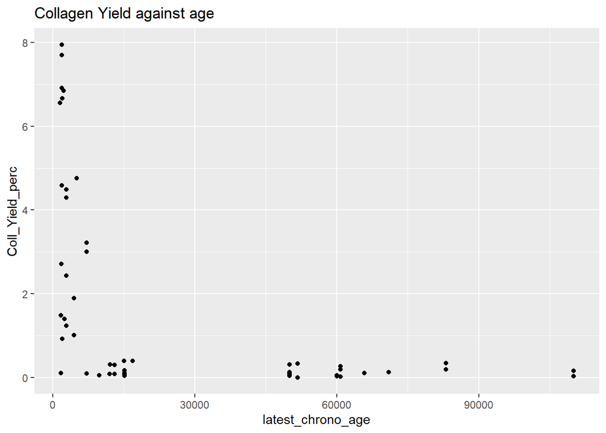

```r
Data_CollagenAge %>%
  ggplot(aes(x = latest_chrono_age, y = Coll_Yield_perc)) +
  geom_jitter() +
  labs(title = "Collagen Yield against age")
```

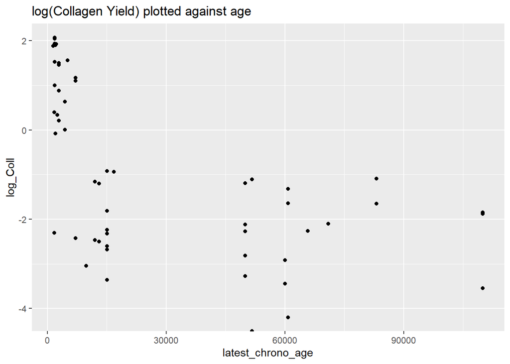

```r
Data_CollagenAge %>%
  ggplot(aes(x = latest_chrono_age, y = log_Coll)) +
  geom_jitter() +
  labs(title = "log(Collagen Yield) plotted against age")
```

#### Histograms

#### Figure out distribution of the data, based on endogenous content

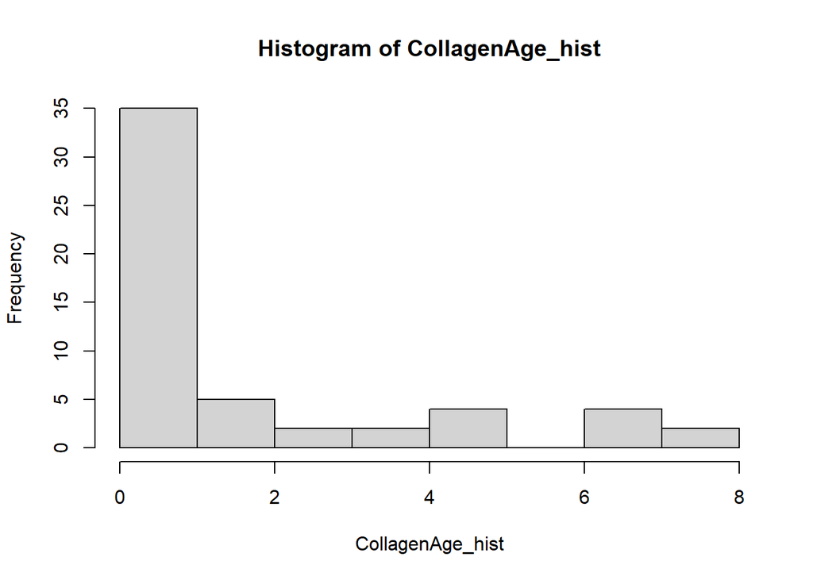

```r
#Filter based just on the endogenous content
CollagenAge_hist <- Data_CollagenAge$Coll_Yield_perc
Log_CollagenAge_hist <- Data_CollagenAge$log_Coll

#Generate the  histogram
hist(CollagenAge_hist)
```

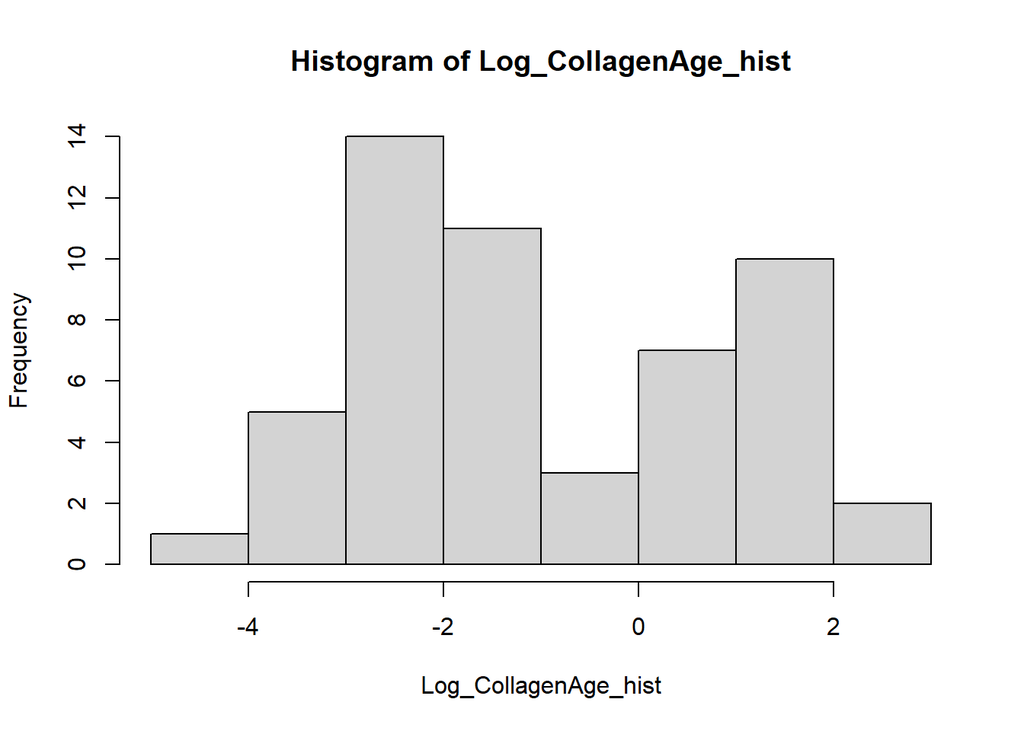

```r
hist(Log_CollagenAge_hist)
```

**Note:** The untransformed data looks as though it follows a gamma distribution and the log-transformed data does not follow a normal distribution. Therefore, use untransformed data and a GLM for a Gamma distribution and a inverse link.

#### Testing various models

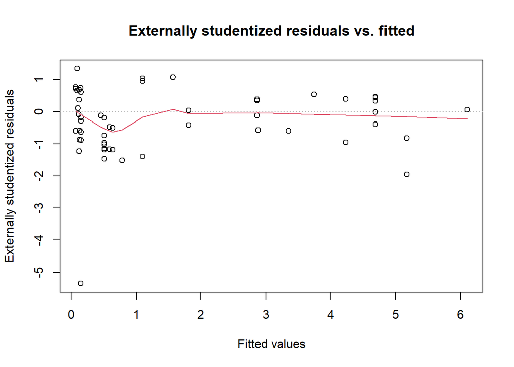

```r
#Use gamma models, but test for the various potential factors

#Added a small variable so that the GLM can be run. There are some 0s in the Collage Yield column.
Data_CollagenAge$Coll_Yield_adj <- Data_CollagenAge$Coll_Yield_perc + 1e-8

#Model only considering the effect of age on collagen yield
GLM_collagen_age <- glm(Coll_Yield_adj ~ latest_chrono_age, data = Data_CollagenAge,
                       family = Gamma(link = "inverse"))
RVAideMemoire::plotresid(GLM_collagen_age)
```

```r
summary(GLM_collagen_age)
```

```
##
## Call:
## glm(formula = Coll_Yield_adj ~ latest_chrono_age, family = Gamma(link = "inverse"),
##     data = Data_CollagenAge)
##
## Deviance Residuals:
##     Min       1Q   Median       3Q      Max
## -5.5692  -1.1309  -0.3064   0.4901   1.6567
##
## Coefficients:
##                     Estimate Std. Error t value Pr(>|t|)
## (Intercept)       -3.372e-02  7.292e-02  -0.462    0.646
## latest_chrono_age  1.316e-04  2.187e-05   6.019  1.8e-07 ***
## ---
## Signif. codes:  0 '***' 0.001 '**' 0.01 '*' 0.05 '.' 0.1 ' ' 1
##
## (Dispersion parameter for Gamma family taken to be 0.8508621)
##
##     Null deviance: 184.411  on 53  degrees of freedom
## Residual deviance:  87.347  on 52  degrees of freedom
##   (26 observations deleted due to missingness)
## AIC: 63.527
##
## Number of Fisher Scoring iterations: 6
```

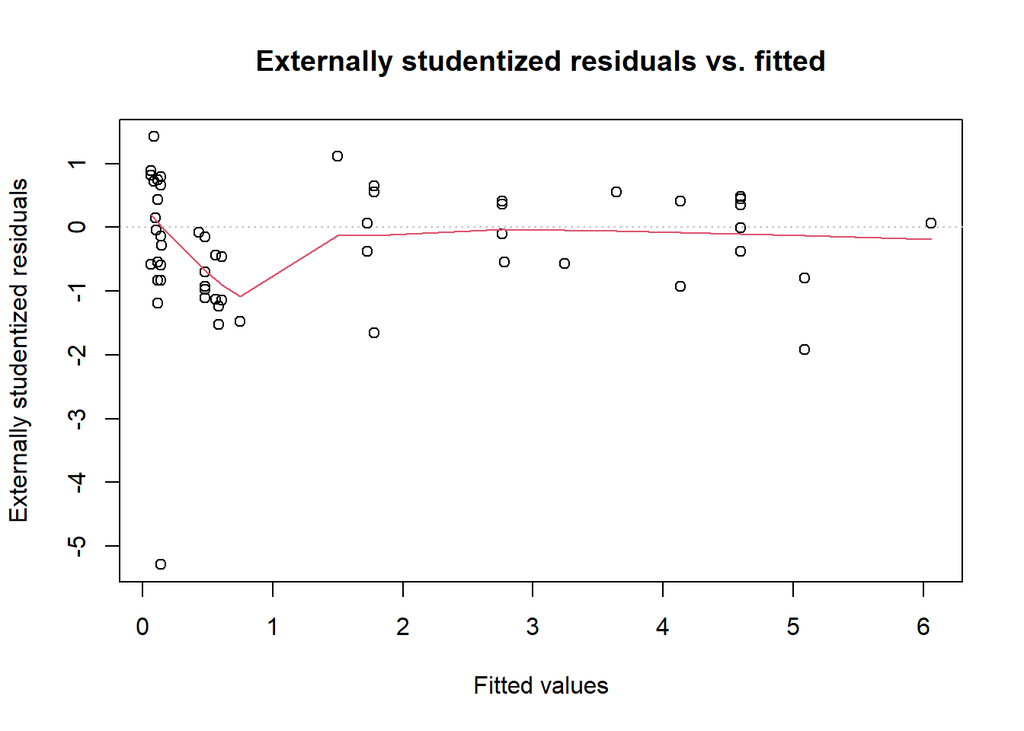

```r
#Model considering the effect of age and its interaction with site on collagen yield
# Note: Does not run, because sampling is to uneven across sites (both in sample size and age range)
## Set levels, so that all sites are compared to NBC. See also options("contrasts")
#Data_CollagenAge$Site_short <- factor(Data_CollagenAge$Site_short,
#                         levels = c("NBC", "DK1", "EBC", "KRM", "BPA", "BNK1"))
#GLM_SS_collagen_age <- glm(Coll_Yield_adj ~ latest_chrono_age * Site_short, data = Data_CollagenAge,
#                         family = Gamma(link = "inverse"))
#RVAideMemoire::plotresid(GLM_SS_collagen_age)
#summary(GLM_SS_collagen_age)

#Model considering the effect of age and its interaction with material group on collagen yield
## Set levels, so that tooth is the reference. See also options("contrasts")
Data_CollagenAge$material_group <- factor(Data_CollagenAge$material_group,
                              levels = c("Tooth", "Bone"))
GLM_MG_collagen_age <- glm(Coll_Yield_adj ~ latest_chrono_age * material_group, data = Data_CollagenAge,
                          family = Gamma(link = "inverse"))
RVAideMemoire::plotresid(GLM_MG_collagen_age)
```

```r
summary(GLM_MG_collagen_age)
```

```
##
## Call:
## glm(formula = Coll_Yield_adj ~ latest_chrono_age * material_group,
##     family = Gamma(link = "inverse"), data = Data_CollagenAge)
##
## Deviance Residuals:
##     Min       1Q   Median       3Q      Max
## -5.5587  -1.0917  -0.2676   0.5274   1.7531
##
## Coefficients:
##                                        Estimate Std. Error t value Pr(>|t|)
## (Intercept)                          -4.455e-02  7.993e-02  -0.557    0.580
## latest_chrono_age                     1.397e-04  2.670e-05   5.234 3.29e-06 ***
## material_groupBone                   -4.287e-01  5.558e-01  -0.771    0.444
## latest_chrono_age:material_groupBone  4.598e-06  6.422e-05   0.072    0.943
## ---
## Signif. codes:  0 '***' 0.001 '**' 0.01 '*' 0.05 '.' 0.1 ' ' 1
##
## (Dispersion parameter for Gamma family taken to be 0.851564)
##
##     Null deviance: 184.411  on 53  degrees of freedom
## Residual deviance:  86.374  on 50  degrees of freedom
##   (26 observations deleted due to missingness)
## AIC: 66.783
##
## Number of Fisher Scoring iterations: 6
```

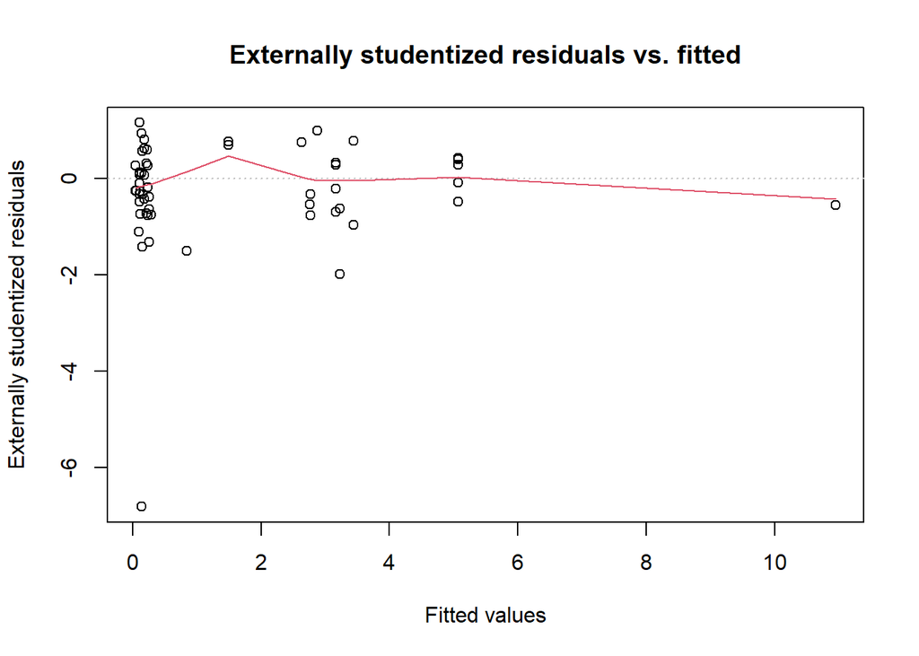

```r
#Model considering the effect of age and its interaction with taxon on collagen yield
## Set levels, so that all species are compared to Cape buffalo. See also options("contrasts")
Data_CollagenAge$Taxon_plots_common <- factor(Data_CollagenAge$Taxon_plots_common,
                         levels = c("Cape buffalo", "Cape grysbok", "Common eland", "Grey rhebok", "Long-horned buffalo", "Reedbuck"))
GLM_TP_collagen_age <- glm(Coll_Yield_adj ~ latest_chrono_age * Taxon_plots_common, data = Data_CollagenAge,
                             family = Gamma(link = "inverse"))
RVAideMemoire::plotresid(GLM_TP_collagen_age)
```

```r
summary(GLM_TP_collagen_age)
```

```
##
## Call:
## glm(formula = Coll_Yield_adj ~ latest_chrono_age * Taxon_plots_common,
##     family = Gamma(link = "inverse"), data = Data_CollagenAge)
##
## Deviance Residuals:
##     Min       1Q   Median       3Q      Max
## -5.5578  -0.6704  -0.2577   0.3664   1.2198
##
## Coefficients:
##                                                           Estimate Std. Error
## (Intercept)                                             -0.3326478  0.2063284
## latest_chrono_age                                        0.0002827  0.0001176
## Taxon_plots_commonCape grysbok                           0.5636635  0.3465112
## Taxon_plots_commonCommon eland                          -0.3982908  3.5789431
## Taxon_plots_commonGrey rhebok                            0.5292084  0.2501681
## Taxon_plots_commonLong-horned buffalo                   10.4557481  4.3438331
## Taxon_plots_commonReedbuck                               8.7811997  4.7053556
## latest_chrono_age:Taxon_plots_commonCape grysbok        -0.0002534  0.0001451
## latest_chrono_age:Taxon_plots_commonCommon eland         0.0001282  0.0002594
## latest_chrono_age:Taxon_plots_commonGrey rhebok         -0.0002168  0.0001201
## latest_chrono_age:Taxon_plots_commonLong-horned buffalo -0.0003389  0.0001301
## latest_chrono_age:Taxon_plots_commonReedbuck            -0.0002691  0.0001439
##                                                         t value Pr(>|t|)
## (Intercept)                                              -1.612   0.1144
## latest_chrono_age                                         2.404   0.0207 *
## Taxon_plots_commonCape grysbok                            1.627   0.1113
## Taxon_plots_commonCommon eland                           -0.111   0.9119
## Taxon_plots_commonGrey rhebok                             2.115   0.0404 *
## Taxon_plots_commonLong-horned buffalo                     2.407   0.0206 *
## Taxon_plots_commonReedbuck                                1.866   0.0690 .
## latest_chrono_age:Taxon_plots_commonCape grysbok         -1.746   0.0880 .
## latest_chrono_age:Taxon_plots_commonCommon eland          0.494   0.6237
## latest_chrono_age:Taxon_plots_commonGrey rhebok          -1.805   0.0783 .
## latest_chrono_age:Taxon_plots_commonLong-horned buffalo  -2.605   0.0127 *
## latest_chrono_age:Taxon_plots_commonReedbuck             -1.870   0.0685 .
## ---
## Signif. codes:  0 '***' 0.001 '**' 0.01 '*' 0.05 '.' 0.1 ' ' 1
##
## (Dispersion parameter for Gamma family taken to be 0.6029418)
##
##     Null deviance: 184.411  on 53  degrees of freedom
## Residual deviance:  62.746  on 42  degrees of freedom
##   (26 observations deleted due to missingness)
## AIC: 62.051
##
## Number of Fisher Scoring iterations: 6
```

```r
#Calculate the AIC/AIcc values for each model (AICc corrects for small sample sizes, as is the case here)
AIC(GLM_collagen_age, GLM_MG_collagen_age, GLM_TP_collagen_age)
```

```
##                     df      AIC
## GLM_collagen_age     3 63.52743
## GLM_MG_collagen_age  5 66.78332
## GLM_TP_collagen_age 13 62.05141
```

```r
purrr::map_dbl(list(GLM_collagen_age = GLM_collagen_age, GLM_MG_collagen_age = GLM_MG_collagen_age, GLM_TP_collagen_age = GLM_TP_collagen_age),
  performance::performance_aicc)
```

```
##    GLM_collagen_age GLM_MG_collagen_age GLM_TP_collagen_age
##            64.00743            68.03332            71.15141
```

**Note:** The GLM_collagen_age seems to fit pretty well and its AICc value is the lowest.

1. Independence (horizontal red line) looks ok

```r
#Linear model with Site included

#ANOVA
car::Anova(GLM_collagen_age, type = "II")
```

```
## Analysis of Deviance Table (Type II tests)
##
## Response: Coll_Yield_adj
##                   LR Chisq Df Pr(>Chisq)
## latest_chrono_age   114.08  1  < 2.2e-16 ***
## ---
## Signif. codes:  0 '***' 0.001 '**' 0.01 '*' 0.05 '.' 0.1 ' ' 1
```

```r
#To calculate the deviance explained by the model
1 - (GLM_collagen_age$deviance / GLM_collagen_age$null.deviance)
```

```
## [1] 0.5263458
```

## 2.1. Summary of collagen yield vs age

In this analysis, untransformed data appeared to have a Gamma distribution and could be analysed using a generalized linear model with an “inverse” link. Various models were tested, taking into account additional factors like species of origin, and material (site of origin could not be tested due to uneven distribution of samples across sites and age).

Overall, the best and most biologically-relevant model was the glm model that only took into account age. The independence looked correct according to the resid plots.

1. The model explained approximately 52% of the deviance in collagen yield.
2. Collagen yield is significantly impacted by age (ANOVA), LR Chisq = 114.08, Df = 1, p < 0.001

# 3. ENDOGENOUS DNA CONTENT VS COLLAGEN YIELD

#### Load data in

```r
Data <- read_csv("Table S3 - paleomix nuclear & collagen.csv")

#Log transform the endogenous content column
Data$log_endo <- log(Data$noMicro_endoPropxTarget)

# Filter for Phase 1 samples, which have both DNA and collagen data
Data_Collagen <- Data %>% filter(StudyPhase == "Phase 1")
```

#### Create plot of collagen vs endogenous content

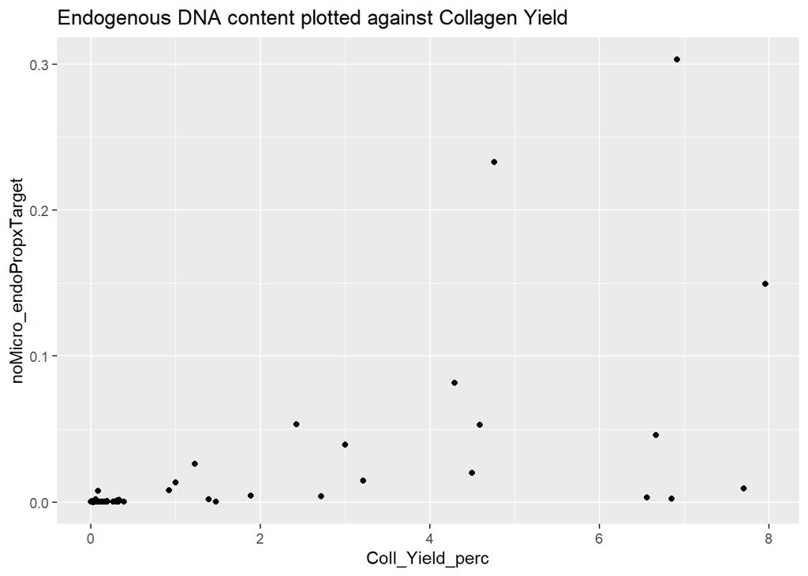

```r
Data_Collagen %>%
  ggplot(aes(x = Coll_Yield_perc, y = noMicro_endoPropxTarget)) +
  geom_jitter() +
  labs(title = "Endogenous DNA content plotted against Collagen Yield")
```

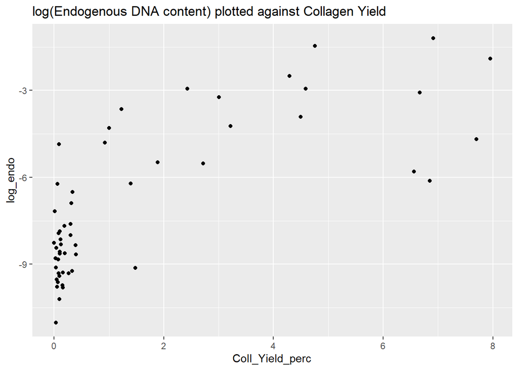

```r
Data_Collagen %>%
  ggplot(aes(x = Coll_Yield_perc, y = log_endo)) +
  geom_jitter() +
  labs(title = "log(Endogenous DNA content) plotted against Collagen Yield")
```

#### Histograms

#### Figure out distribution of the data, based on endogenous content

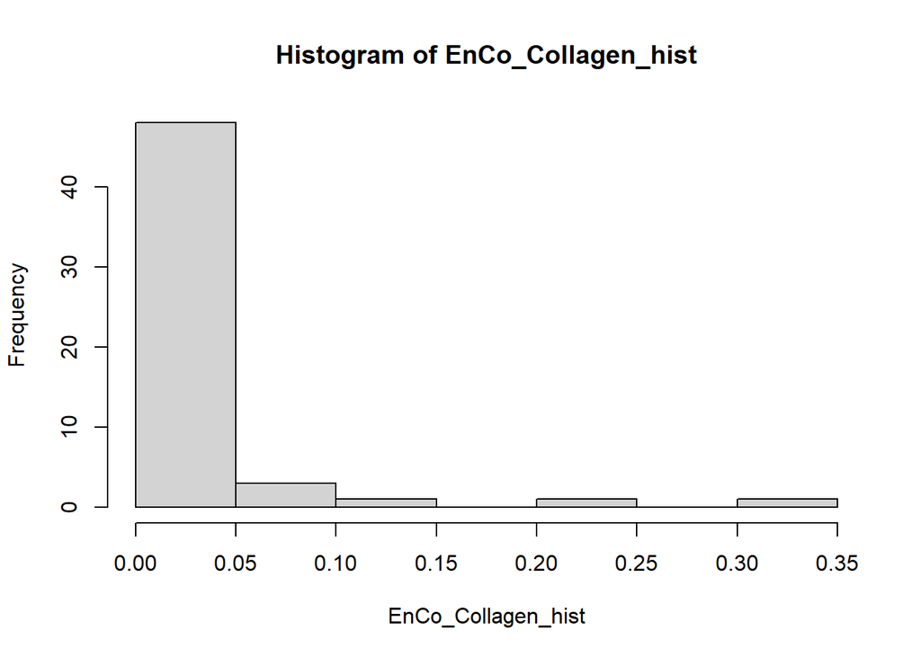

```r
#Filter based just on the endogenous content
EnCo_Collagen_hist <- Data_Collagen$noMicro_endoPropxTarget
LogEnCo_Collagen_hist <- Data_Collagen$log_endo

#Generate the  histogram
hist(EnCo_Collagen_hist)
```

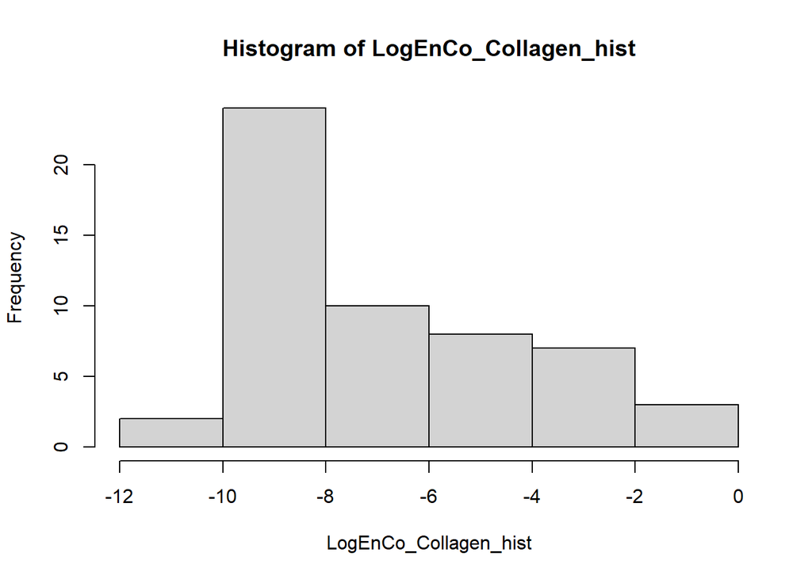

```r
hist(LogEnCo_Collagen_hist)
```

**Note:** The log transformed data looks liked it might be more or less normally distributed, so test out linear models based on gaussian (=normal) distributions. Also doing this because both variables are continuous.

#### Testing various models

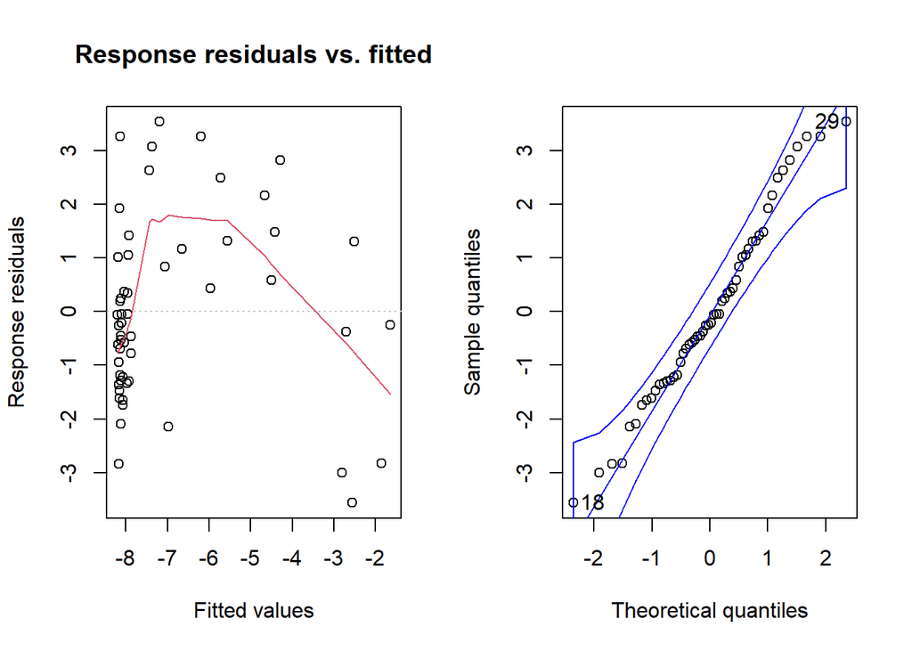

```r
#Use linear models for all, but test for the various potential factors

#Model only considering the effect of age on endogenous content
LM_collagen <- lm(log_endo ~ Coll_Yield_perc, data = Data_Collagen)
RVAideMemoire::plotresid(LM_collagen)
```

```r
summary(LM_collagen)
```

```
##
## Call:
## lm(formula = log_endo ~ Coll_Yield_perc, data = Data_Collagen)
##
## Residuals:
##     Min      1Q  Median      3Q     Max
## -3.5633 -1.2709 -0.2334  1.1341  3.5377
##
## Coefficients:
##                 Estimate Std. Error t value Pr(>|t|)
## (Intercept)      -8.2034     0.2841 -28.875  < 2e-16 ***
## Coll_Yield_perc   0.8242     0.1004   8.206 6.03e-11 ***
## ---
## Signif. codes:  0 '***' 0.001 '**' 0.01 '*' 0.05 '.' 0.1 ' ' 1
##
## Residual standard error: 1.734 on 52 degrees of freedom
##   (26 observations deleted due to missingness)
## Multiple R-squared:  0.5643, Adjusted R-squared:  0.5559
## F-statistic: 67.34 on 1 and 52 DF,  p-value: 6.028e-11
```

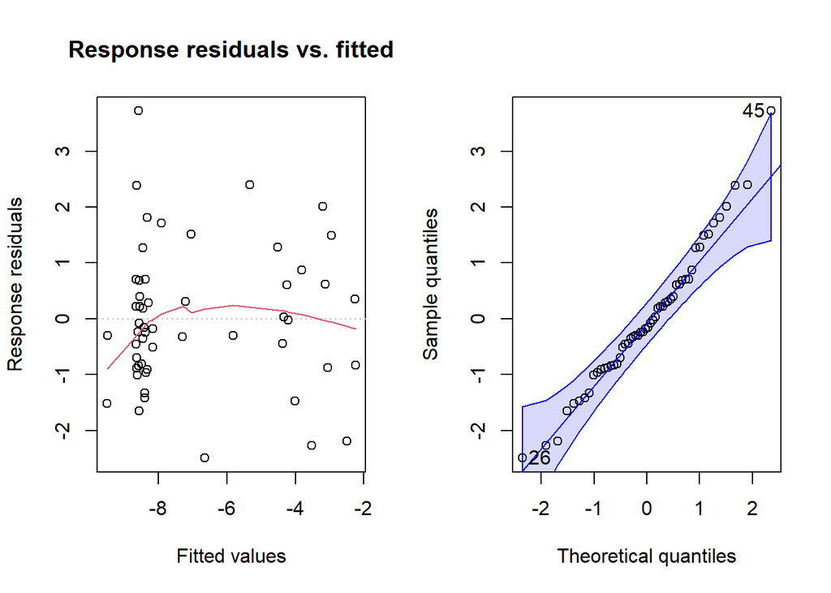

```r
#Model considering the effect of age and its interaction with site on endogenous content
## Set levels, so that all sites are compared to NBC. See also options("contrasts")
Data_Collagen$Site_short <- factor(Data_Collagen$Site_short,
                         levels = c("NBC", "DK1", "EBC", "KRM", "BPA", "BNK1"))
LM_SS_collagen <- lm(log_endo ~ Coll_Yield_perc * Site_short, data = Data_Collagen)
RVAideMemoire::plotresid(LM_SS_collagen)
```

```r
summary(LM_SS_collagen)
```

```
##
## Call:
## lm(formula = log_endo ~ Coll_Yield_perc * Site_short, data = Data_Collagen)
##
## Residuals:
##     Min      1Q  Median      3Q     Max
## -2.4921 -0.8402 -0.1687  0.6693  3.7203
##
## Coefficients:
##                               Estimate Std. Error t value Pr(>|t|)
## (Intercept)                   -4.70682    0.85870  -5.481 1.94e-06 ***
## Coll_Yield_perc                0.36899    0.23658   1.560 0.125995
## Site_shortDK1                 -4.81787    1.22017  -3.949 0.000280 ***
## Site_shortEBC                 -4.44366    1.62055  -2.742 0.008795 **
## Site_shortKRM                 -3.74727    0.95277  -3.933 0.000294 ***
## Site_shortBPA                 -3.99785    0.92638  -4.316 8.89e-05 ***
## Coll_Yield_perc:Site_shortDK1  0.54469    0.28430   1.916 0.061889 .
## Coll_Yield_perc:Site_shortEBC  5.84937    6.13525   0.953 0.345594
## Coll_Yield_perc:Site_shortKRM  0.01608    0.31767   0.051 0.959861
## Coll_Yield_perc:Site_shortBPA  1.02641    0.40677   2.523 0.015312 *
## ---
## Signif. codes:  0 '***' 0.001 '**' 0.01 '*' 0.05 '.' 0.1 ' ' 1
##
## Residual standard error: 1.367 on 44 degrees of freedom
##   (26 observations deleted due to missingness)
## Multiple R-squared:  0.771,  Adjusted R-squared:  0.7242
## F-statistic: 16.46 on 9 and 44 DF,  p-value: 2.083e-11
```

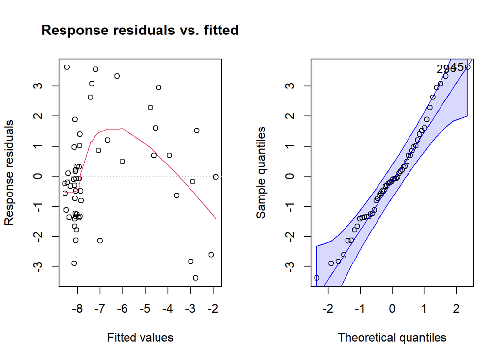

```r
#Model considering the effect of age and its interaction with material group on endogenous content
## Set levels, so that tooth is the reference. See also options("contrasts")
Data_Collagen$material_group <- factor(Data_Collagen$material_group,
                              levels = c("Tooth", "Bone"))
LM_MG_collagen <- lm(log_endo ~ Coll_Yield_perc * material_group, data = Data_Collagen)
RVAideMemoire::plotresid(LM_MG_collagen)
```

```r
summary(LM_MG_collagen)
```

```
##
## Call:
## lm(formula = log_endo ~ Coll_Yield_perc * material_group, data = Data_Collagen)
##
## Residuals:
##     Min      1Q  Median      3Q     Max
## -3.3630 -1.2428 -0.1364  0.9464  3.6098
##
## Coefficients:
##                                    Estimate Std. Error t value Pr(>|t|)
## (Intercept)                         -8.1667     0.3183 -25.659  < 2e-16 ***
## Coll_Yield_perc                      0.7896     0.1039   7.597 7.02e-10 ***
## material_groupBone                  -0.4418     0.7055  -0.626    0.534
## Coll_Yield_perc:material_groupBone   0.7670     0.4632   1.656    0.104
## ---
## Signif. codes:  0 '***' 0.001 '**' 0.01 '*' 0.05 '.' 0.1 ' ' 1
##
## Residual standard error: 1.721 on 50 degrees of freedom
##   (26 observations deleted due to missingness)
## Multiple R-squared:  0.5873, Adjusted R-squared:  0.5625
## F-statistic: 23.72 on 3 and 50 DF,  p-value: 1.093e-09
```

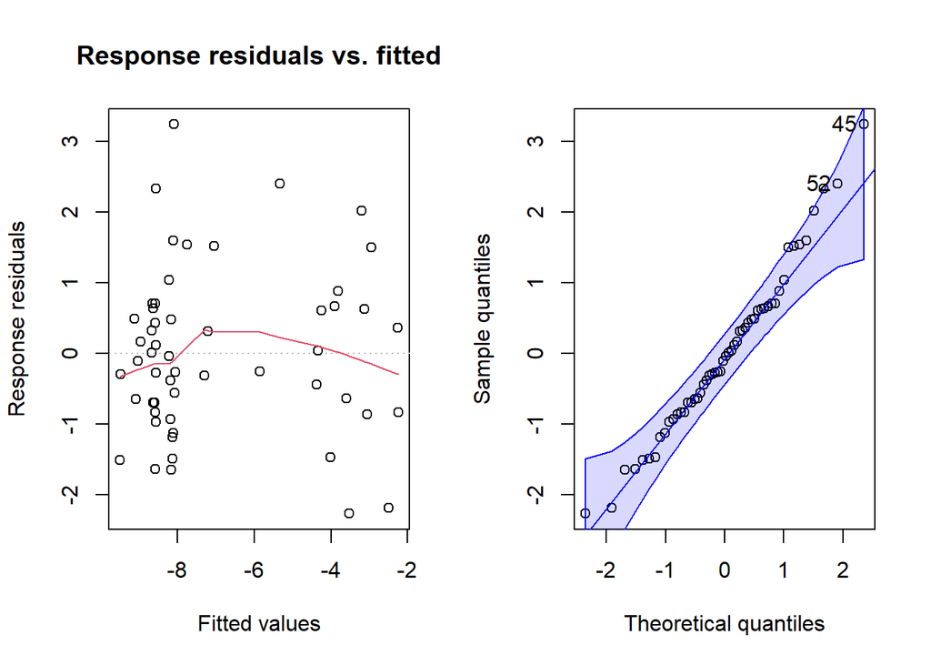

```r
#Model considering the effect of age and its interaction with site and material group on endogenous content
LM_SS_MG_collagen <- lm(log_endo ~ Coll_Yield_perc * Site_short * material_group, data = Data_Collagen)
RVAideMemoire::plotresid(LM_SS_MG_collagen)
```

```r
summary(LM_SS_MG_collagen)
```

```
##
## Call:
## lm(formula = log_endo ~ Coll_Yield_perc * Site_short * material_group,
##     data = Data_Collagen)
##
## Residuals:
##     Min      1Q  Median      3Q     Max
## -2.2702 -0.7987 -0.0759  0.6317  3.2371
##
## Coefficients: (6 not defined because of singularities)
##                                                  Estimate Std. Error t value
## (Intercept)                                      -4.70682    0.84414  -5.576
## Coll_Yield_perc                                   0.36899    0.23257   1.587
## Site_shortDK1                                    -4.81787    1.19948  -4.017
## Site_shortEBC                                    -4.44366    1.59307  -2.789
## Site_shortKRM                                    -3.51548    0.96705  -3.635
## Site_shortBPA                                    -3.83183    0.95867  -3.997
## material_groupBone                                0.31326    0.76689   0.408
## Coll_Yield_perc:Site_shortDK1                     0.54469    0.27948   1.949
## Coll_Yield_perc:Site_shortEBC                     5.84937    6.03122   0.970
## Coll_Yield_perc:Site_shortKRM                    -0.02408    0.31513  -0.076
## Coll_Yield_perc:Site_shortBPA                    -0.69576    1.02901  -0.676
## Coll_Yield_perc:material_groupBone                1.76650    1.06889   1.653
## Site_shortDK1:material_groupBone                       NA         NA      NA
## Site_shortEBC:material_groupBone                       NA         NA      NA
## Site_shortKRM:material_groupBone                 -1.02861    1.82298  -0.564
## Site_shortBPA:material_groupBone                       NA         NA      NA
## Coll_Yield_perc:Site_shortDK1:material_groupBone       NA         NA      NA
## Coll_Yield_perc:Site_shortEBC:material_groupBone       NA         NA      NA
## Coll_Yield_perc:Site_shortKRM:material_groupBone -3.00881   11.13990  -0.270
## Coll_Yield_perc:Site_shortBPA:material_groupBone       NA         NA      NA
##                                                  Pr(>|t|)
## (Intercept)                                      1.86e-06 ***
## Coll_Yield_perc                                  0.120477
## Site_shortDK1                                    0.000253 ***
## Site_shortEBC                                    0.008049 **
## Site_shortKRM                                    0.000783 ***
## Site_shortBPA                                    0.000268 ***
## material_groupBone                               0.685102
## Coll_Yield_perc:Site_shortDK1                    0.058339 .
## Coll_Yield_perc:Site_shortEBC                    0.337950
## Coll_Yield_perc:Site_shortKRM                    0.939483
## Coll_Yield_perc:Site_shortBPA                    0.502842
## Coll_Yield_perc:material_groupBone               0.106231
## Site_shortDK1:material_groupBone                       NA
## Site_shortEBC:material_groupBone                       NA
## Site_shortKRM:material_groupBone                 0.575737
## Site_shortBPA:material_groupBone                       NA
## Coll_Yield_perc:Site_shortDK1:material_groupBone       NA
## Coll_Yield_perc:Site_shortEBC:material_groupBone       NA
## Coll_Yield_perc:Site_shortKRM:material_groupBone 0.788478
## Coll_Yield_perc:Site_shortBPA:material_groupBone       NA
## ---
## Signif. codes:  0 '***' 0.001 '**' 0.01 '*' 0.05 '.' 0.1 ' ' 1
##
## Residual standard error: 1.344 on 40 degrees of freedom
##   (26 observations deleted due to missingness)
## Multiple R-squared:  0.7989, Adjusted R-squared:  0.7335
## F-statistic: 12.22 on 13 and 40 DF,  p-value: 4.106e-10
```

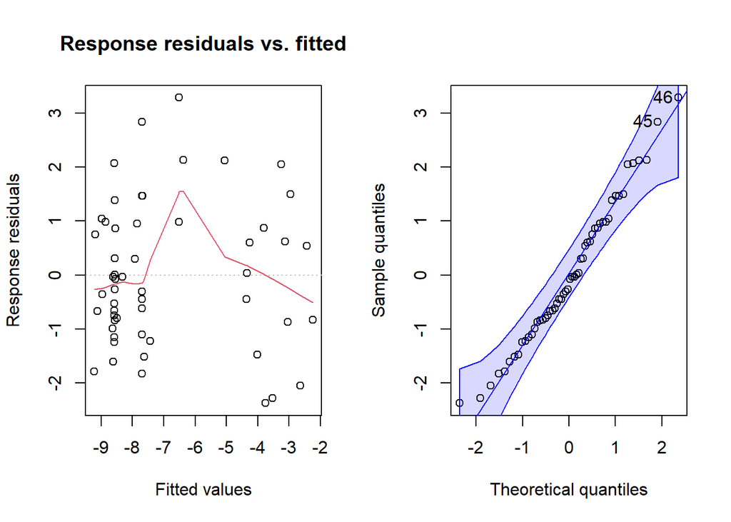

```r
#Model considering the effect of age and its interaction with the taxon on endogenous content
## Set levels, so that all species are compared to Cape buffalo. See also options("contrasts")
Data_Collagen$Taxon_plots_common <- factor(Data_Collagen$Taxon_plots_common,
                         levels = c("Cape buffalo", "Cape grysbok", "Common eland", "Grey rhebok", "Long-horned buffalo", "Reedbuck"))
LM_TP_collagen <- lm(log_endo ~ Coll_Yield_perc * Taxon_plots_common, data = Data_Collagen)
RVAideMemoire::plotresid(LM_TP_collagen)
```

```r
summary(LM_TP_collagen)
```

```
##
## Call:
## lm(formula = log_endo ~ Coll_Yield_perc * Taxon_plots_common,
##     data = Data_Collagen)
##
## Residuals:
##     Min      1Q  Median      3Q     Max
## -2.3731 -0.8630 -0.1747  0.9339  3.2847
##
## Coefficients:
##                                                       Estimate Std. Error
## (Intercept)                                           -8.61242    0.81355
## Coll_Yield_perc                                        0.77585    0.15688
## Taxon_plots_commonCape grysbok                         3.90560    1.23847
## Taxon_plots_commonCommon eland                        -0.76347    1.11948
## Taxon_plots_commonGrey rhebok                         -0.07010    0.98813
## Taxon_plots_commonLong-horned buffalo                  0.04519    1.14065
## Taxon_plots_commonReedbuck                             0.91599    1.22590
## Coll_Yield_perc:Taxon_plots_commonCape grysbok        -0.40686    0.30132
## Coll_Yield_perc:Taxon_plots_commonCommon eland         4.11241    3.77378
## Coll_Yield_perc:Taxon_plots_commonGrey rhebok         -0.05542    0.27142
## Coll_Yield_perc:Taxon_plots_commonLong-horned buffalo -0.79705    4.08355
## Coll_Yield_perc:Taxon_plots_commonReedbuck            -0.78451    6.59810
##                                                       t value Pr(>|t|)
## (Intercept)                                           -10.586 1.99e-13 ***
## Coll_Yield_perc                                         4.946 1.27e-05 ***
## Taxon_plots_commonCape grysbok                          3.154  0.00298 **
## Taxon_plots_commonCommon eland                         -0.682  0.49899
## Taxon_plots_commonGrey rhebok                          -0.071  0.94378
## Taxon_plots_commonLong-horned buffalo                   0.040  0.96858
## Taxon_plots_commonReedbuck                              0.747  0.45911
## Coll_Yield_perc:Taxon_plots_commonCape grysbok         -1.350  0.18417
## Coll_Yield_perc:Taxon_plots_commonCommon eland          1.090  0.28204
## Coll_Yield_perc:Taxon_plots_commonGrey rhebok          -0.204  0.83919
## Coll_Yield_perc:Taxon_plots_commonLong-horned buffalo  -0.195  0.84619
## Coll_Yield_perc:Taxon_plots_commonReedbuck             -0.119  0.90592
## ---
## Signif. codes:  0 '***' 0.001 '**' 0.01 '*' 0.05 '.' 0.1 ' ' 1
##
## Residual standard error: 1.486 on 42 degrees of freedom
##   (26 observations deleted due to missingness)
## Multiple R-squared:  0.7416, Adjusted R-squared:  0.6739
## F-statistic: 10.96 on 11 and 42 DF,  p-value: 3.761e-09
```

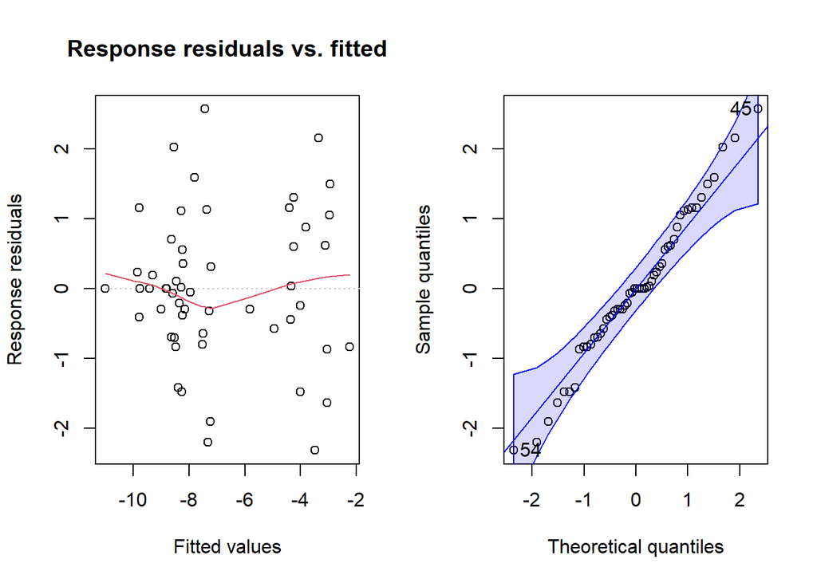

```r
#Model considering the effect of age and its interaction with site and taxon on endogenous content
LM_SS_TP_collagen <- lm(log_endo ~ Coll_Yield_perc * Site_short * Taxon_plots_common, data = Data_Collagen)
RVAideMemoire::plotresid(LM_SS_TP_collagen)
```

```r
summary(LM_SS_TP_collagen)
```

```
##
## Call:
## lm(formula = log_endo ~ Coll_Yield_perc * Site_short * Taxon_plots_common,
##     data = Data_Collagen)
##
## Residuals:
##     Min      1Q  Median      3Q     Max
## -2.3131 -0.6227  0.0000  0.6144  2.5694
##
## Coefficients: (37 not defined because of singularities)
##                                                                      Estimate
## (Intercept)                                                          -4.70682
## Coll_Yield_perc                                                       0.36899
## Site_shortDK1                                                        -1.28442
## Site_shortEBC                                                        -5.73283
## Site_shortKRM                                                        -6.86975
## Site_shortBPA                                                        -4.67907
## Taxon_plots_commonCape grysbok                                             NA
## Taxon_plots_commonCommon eland                                        1.28917
## Taxon_plots_commonGrey rhebok                                        -0.60006
## Taxon_plots_commonLong-horned buffalo                                 2.34714
## Taxon_plots_commonReedbuck                                            2.17202
## Coll_Yield_perc:Site_shortDK1                                         0.01267
## Coll_Yield_perc:Site_shortEBC                                         9.50551
## Coll_Yield_perc:Site_shortKRM                                        25.58848
## Coll_Yield_perc:Site_shortBPA                                         2.03230
## Coll_Yield_perc:Taxon_plots_commonCape grysbok                             NA
## Coll_Yield_perc:Taxon_plots_commonCommon eland                       -3.65614
## Coll_Yield_perc:Taxon_plots_commonGrey rhebok                        -0.53948
## Coll_Yield_perc:Taxon_plots_commonLong-horned buffalo               -26.73013
## Coll_Yield_perc:Taxon_plots_commonReedbuck                           -4.83228
## Site_shortDK1:Taxon_plots_commonCape grysbok                               NA
## Site_shortEBC:Taxon_plots_commonCape grysbok                               NA
## Site_shortKRM:Taxon_plots_commonCape grysbok                               NA
## Site_shortBPA:Taxon_plots_commonCape grysbok                               NA
## Site_shortDK1:Taxon_plots_commonCommon eland                         -8.07720
## Site_shortEBC:Taxon_plots_commonCommon eland                               NA
## Site_shortKRM:Taxon_plots_commonCommon eland                               NA
## Site_shortBPA:Taxon_plots_commonCommon eland                               NA
## Site_shortDK1:Taxon_plots_commonGrey rhebok                                NA
```

[output cut: 267 more lines]

```
## Coll_Yield_perc:Site_shortDK1:Taxon_plots_commonLong-horned buffalo
## Coll_Yield_perc:Site_shortEBC:Taxon_plots_commonLong-horned buffalo
## Coll_Yield_perc:Site_shortKRM:Taxon_plots_commonLong-horned buffalo
## Coll_Yield_perc:Site_shortBPA:Taxon_plots_commonLong-horned buffalo
## Coll_Yield_perc:Site_shortDK1:Taxon_plots_commonReedbuck
## Coll_Yield_perc:Site_shortEBC:Taxon_plots_commonReedbuck
## Coll_Yield_perc:Site_shortKRM:Taxon_plots_commonReedbuck
## Coll_Yield_perc:Site_shortBPA:Taxon_plots_commonReedbuck
## ---
## Signif. codes:  0 '***' 0.001 '**' 0.01 '*' 0.05 '.' 0.1 ' ' 1
##
## Residual standard error: 1.381 on 31 degrees of freedom
##   (26 observations deleted due to missingness)
## Multiple R-squared:  0.8354, Adjusted R-squared:  0.7186
## F-statistic: 7.153 on 22 and 31 DF,  p-value: 5.599e-07
```

```r
#Calculate the AIC/AIcc values for each model (AICc required for transformed response variable, as in our case)
AIC(LM_collagen, LM_SS_collagen, LM_MG_collagen, LM_SS_MG_collagen, LM_TP_collagen, LM_SS_TP_collagen)
```

```
##                   df      AIC
## LM_collagen        3 216.6778
## LM_SS_collagen    11 197.9264
## LM_MG_collagen     5 217.7427
## LM_SS_MG_collagen 15 198.9327
## LM_TP_collagen    13 208.4669
## LM_SS_TP_collagen 24 206.0999
```

```r
purrr::map_dbl(list(LM_collagen = LM_collagen, LM_SS_collagen = LM_SS_collagen, LM_MG_collagen = LM_MG_collagen, LM_SS_MG_collagen = LM_SS_MG_collagen, LM_TP_collagen = LM_TP_collagen, LM_SS_TP_collagen = LM_SS_TP_collagen),
  performance::performance_aicc)
```

```
##       LM_collagen    LM_SS_collagen    LM_MG_collagen LM_SS_MG_collagen
##          217.1578          204.2122          218.9927          211.5643
##    LM_TP_collagen LM_SS_TP_collagen
##          217.5669          247.4793
```

**Note:** The LM_SS_collagen (site) seems to fit pretty well and its AICc value is the lowest.

1. Independence (horizontal red line on left handside graph) looks ok
2. homoscedasticity (spread of data above and below 0 on left handside graph) looks good
3. and normality (data points inside blue region on right handside graph) looks good.

```r
#Linear model with Site included

#ANOVA
car::Anova(LM_SS_collagen, type = "II")
```

```
## Anova Table (Type II tests)
##
## Response: log_endo
##                            Sum Sq Df F value    Pr(>F)
## Coll_Yield_perc            87.709  1 46.9561 1.882e-08 ***
## Site_short                 53.358  4  7.1415 0.0001603 ***
## Coll_Yield_perc:Site_short 20.875  4  2.7939 0.0375332 *
## Residuals                  82.188 44
## ---
## Signif. codes:  0 '***' 0.001 '**' 0.01 '*' 0.05 '.' 0.1 ' ' 1
```

## 3.1. Summary of Endogenous DNA Content vs collagen yield

In this analysis, the log-transformed data looked to be normally distributed and thus a linear model was used. Various models were tested, taking into account additional factors like site of origin, species of origin, and material.

Overall, the best and most biologically-relevant model was likely the lm model that took into account site as an experimental variable. The independence, homoscedasticity, and normality looked correct according to the resid plots.

1. Multiple R-squared: 0.7711
2. Adjusted R-squared: 0.7242
3. Collagen yield (percentage) significantly impacted endogenous content, F = 46.9561, Df = 1, p < 0.001
4. Site significantly impacted endogenous content, F = 7.1415, Df = 4, p < 0.001
5. Coll_Yield_perc:Site_short significantly impacted endogenous DNA content: F = 2.7939, Df = 4, p < 0.05

Therefore, collagen yield is partially predictive of endogenous DNA content, together with site. There was a significant effect of the interaction between collagen yield and site.

# 4. READ LENGTH VS AGE

## 4.1. Analyses including only those with true endogenous DNA

#### Filter for specimens where species_identifiable == “Yes”

```r
Data <- read_csv("Table S3 - paleomix nuclear & collagen.csv")

#Log transform the read length (in case needed)
Data$log_rl <- log(Data$noMicro_meanLengthxTarget)

# filter
Data_Yes <- Data %>% filter(species_identifiable == "Yes")
```

#### Create plot of age vs mean read length

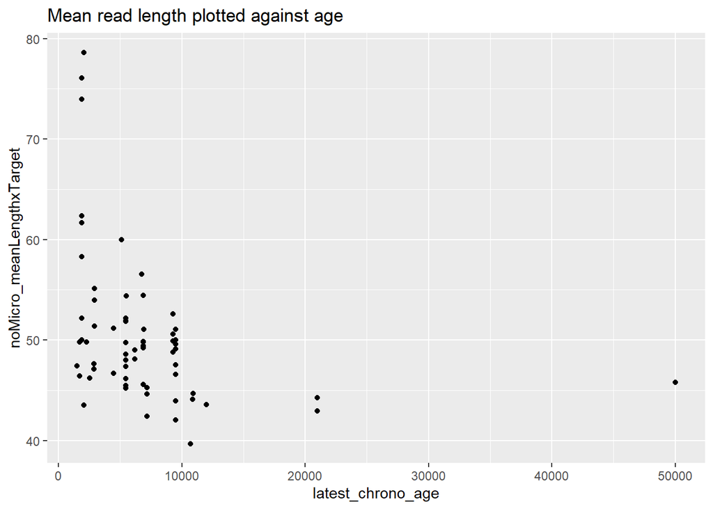

```r
Data_Yes %>%
  ggplot(aes(x = latest_chrono_age, y = noMicro_meanLengthxTarget)) +
  geom_jitter() +
  labs(title = "Mean read length plotted against age")
```

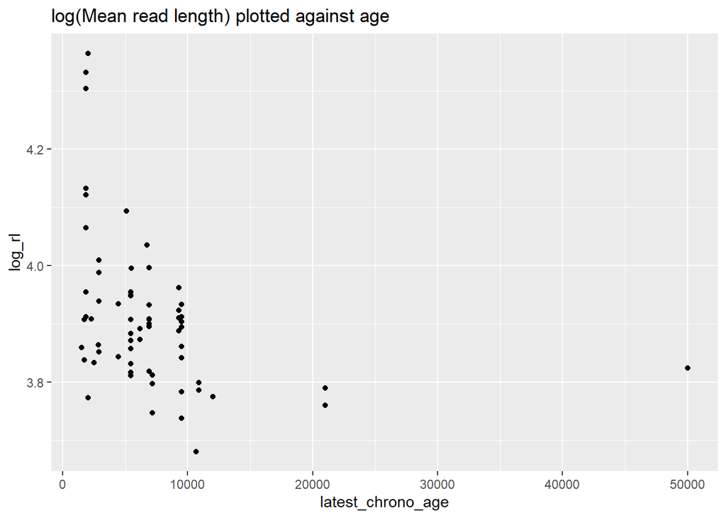

```r
Data_Yes %>%
  ggplot(aes(x = latest_chrono_age, y = log_rl)) +
  geom_jitter() +
  labs(title = "log(Mean read length) plotted against age")
```

#### Histograms

#### Figure out distribution of the data, based on endogenous content

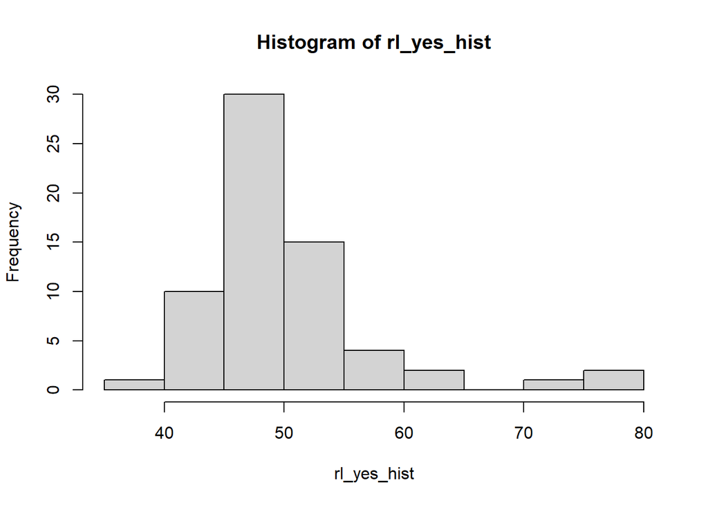

```r
#Filter based just on the endogenous content
rl_yes_hist <- Data_Yes$noMicro_meanLengthxTarget
log_rl_yes_hist <- Data_Yes$log_rl

#Generate the  histogram
hist(rl_yes_hist)
```

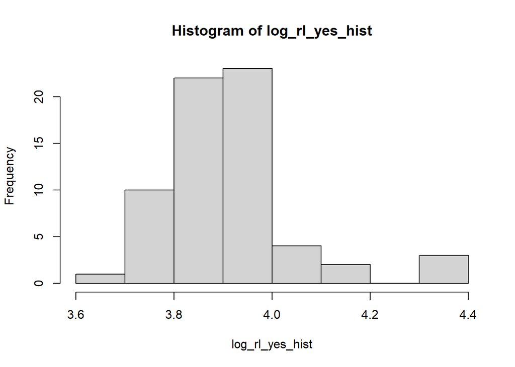

```r
hist(log_rl_yes_hist)
```

**Note:** The log transformed data looks more or less normally distributed, so test out linear models based on gaussian (=normal) distributions

#### Testing various models

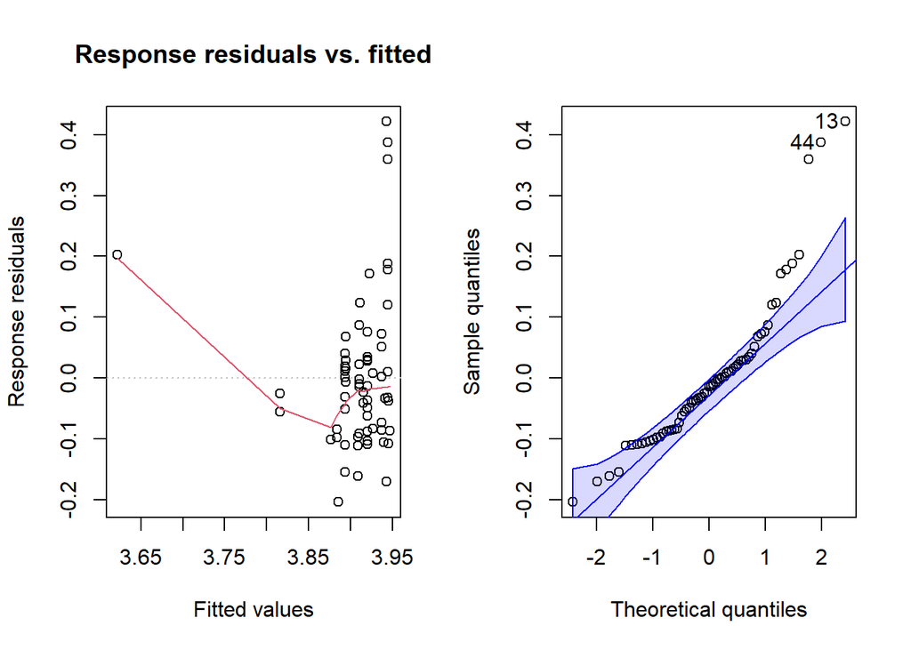

```r
#Use linear models for all, but test for the various potential factors

#Model only considering the effect of age on read length
LM_Yes <- lm(log_rl ~ latest_chrono_age, data = Data_Yes)
RVAideMemoire::plotresid(LM_Yes)
```

```r
summary(LM_Yes)
```

```
##
## Call:
## lm(formula = log_rl ~ latest_chrono_age, data = Data_Yes)
##
## Residuals:
##      Min       1Q   Median       3Q      Max
## -0.20397 -0.08550 -0.01464  0.02948  0.42146
##
## Coefficients:
##                     Estimate Std. Error t value Pr(>|t|)
## (Intercept)        3.957e+00  2.208e-02 179.235  < 2e-16 ***
## latest_chrono_age -6.705e-06  2.289e-06  -2.929  0.00473 **
## ---
## Signif. codes:  0 '***' 0.001 '**' 0.01 '*' 0.05 '.' 0.1 ' ' 1
##
## Residual standard error: 0.1227 on 63 degrees of freedom
##   (4 observations deleted due to missingness)
## Multiple R-squared:  0.1199, Adjusted R-squared:  0.1059
## F-statistic:  8.58 on 1 and 63 DF,  p-value: 0.004726
```

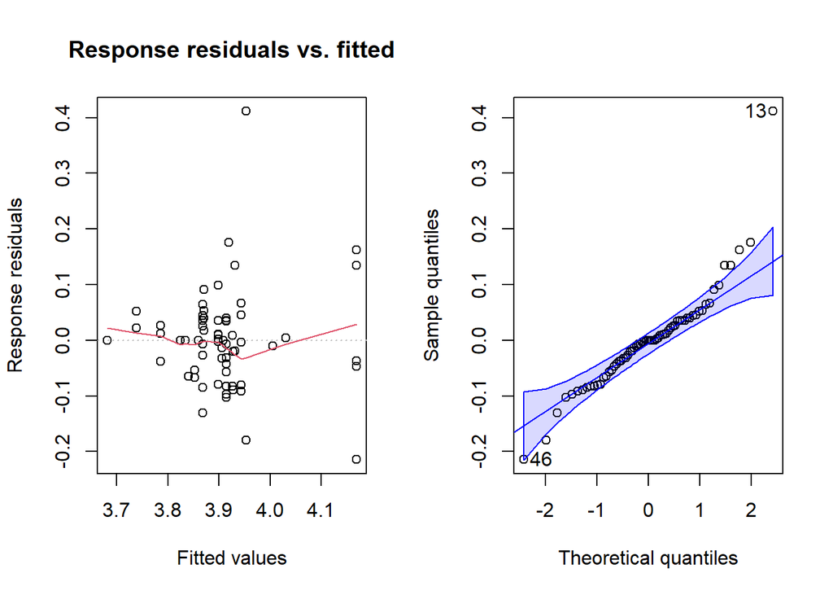

```r
#Model considering the effect of age and its interaction with site on endogenous content
## Set levels, so that all sites are compared to NBC. See also options("contrasts")
Data_Yes$Site_short <- factor(Data_Yes$Site_short,
                         levels = c("NBC", "DK1", "EBC", "KRM", "BPA", "BNK1"))
LM_SS_Yes <- lm(log_rl ~ latest_chrono_age * Site_short, data = Data_Yes)
RVAideMemoire::plotresid(LM_SS_Yes)
```

```r
summary(LM_SS_Yes)
```

```
##
## Call:
## lm(formula = log_rl ~ latest_chrono_age * Site_short, data = Data_Yes)
##
## Residuals:
##      Min       1Q   Median       3Q      Max
## -0.21421 -0.04695  0.00000  0.03532  0.41137
##
## Coefficients: (1 not defined because of singularities)
##                                    Estimate Std. Error t value Pr(>|t|)
## (Intercept)                       3.977e+00  3.039e-02 130.847  < 2e-16 ***
## latest_chrono_age                -1.137e-05  3.669e-06  -3.099  0.00308 **
## Site_shortDK1                    -1.354e+00  5.121e-01  -2.645  0.01068 *
## Site_shortEBC                    -1.737e-01  9.808e-02  -1.771  0.08217 .
## Site_shortKRM                     6.414e-01  1.366e+00   0.469  0.64062
## Site_shortBPA                    -1.970e-01  7.343e-02  -2.683  0.00967 **
## Site_shortBNK1                   -8.455e-02  7.893e-02  -1.071  0.28886
## latest_chrono_age:Site_shortDK1   8.362e-04  2.812e-04   2.974  0.00439 **
## latest_chrono_age:Site_shortEBC          NA         NA      NA       NA
## latest_chrono_age:Site_shortKRM  -2.992e-04  5.672e-04  -0.528  0.59998
## latest_chrono_age:Site_shortBPA   1.227e-05  4.494e-06   2.729  0.00855 **
## latest_chrono_age:Site_shortBNK1  3.204e-05  1.931e-05   1.660  0.10281
## ---
## Signif. codes:  0 '***' 0.001 '**' 0.01 '*' 0.05 '.' 0.1 ' ' 1
##
## Residual standard error: 0.09626 on 54 degrees of freedom
##   (4 observations deleted due to missingness)
## Multiple R-squared:  0.5353, Adjusted R-squared:  0.4493
## F-statistic: 6.222 on 10 and 54 DF,  p-value: 3.021e-06
```

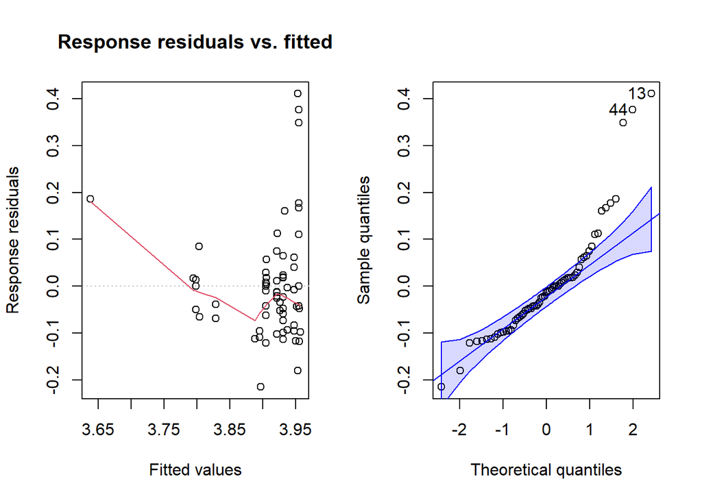

```r
#Model considering the effect of age and its interaction with material group on endogenous content
## Set levels, so that tooth is the reference. See also options("contrasts")
Data_Yes$material_group <- factor(Data_Yes$material_group,
                              levels = c("Tooth", "Bone"))
LM_MG_Yes <- lm(log_rl ~ latest_chrono_age * material_group, data = Data_Yes)
RVAideMemoire::plotresid(LM_MG_Yes)
```

```r
summary(LM_MG_Yes)
```

```
##
## Call:
## lm(formula = log_rl ~ latest_chrono_age * material_group, data = Data_Yes)
##
## Residuals:
##      Min       1Q   Median       3Q      Max
## -0.21525 -0.06849 -0.01345  0.02380  0.41123
##
## Coefficients:
##                                        Estimate Std. Error t value Pr(>|t|)
## (Intercept)                           3.967e+00  2.196e-02 180.666  < 2e-16 ***
## latest_chrono_age                    -6.584e-06  2.237e-06  -2.943  0.00459 **
## material_groupBone                   -1.849e-01  2.731e-01  -0.677  0.50086
## latest_chrono_age:material_groupBone  8.855e-06  3.516e-05   0.252  0.80203
## ---
## Signif. codes:  0 '***' 0.001 '**' 0.01 '*' 0.05 '.' 0.1 ' ' 1
##
## Residual standard error: 0.1196 on 61 degrees of freedom
##   (4 observations deleted due to missingness)
## Multiple R-squared:  0.1903, Adjusted R-squared:  0.1505
## F-statistic: 4.779 on 3 and 61 DF,  p-value: 0.004678
```

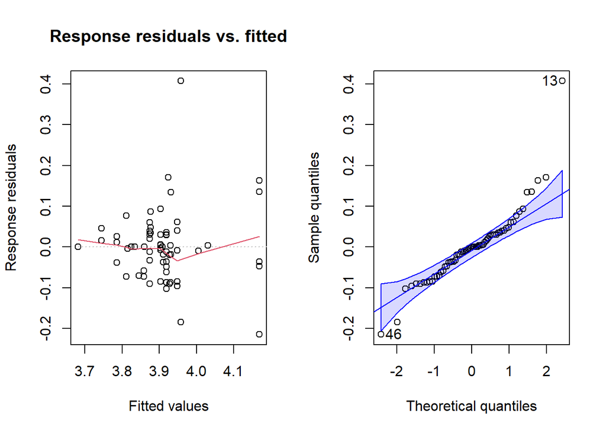

```r
#Model considering the effect of age and its interaction with site and material group on endogenous content
## Set levels, so that tooth is the reference. See also options("contrasts")
Data_Yes$material_group <- factor(Data_Yes$material_group,
                              levels = c("Tooth", "Bone"))
LM_SS_MG_Yes <- lm(log_rl ~ latest_chrono_age * Site_short * material_group, data = Data_Yes)
RVAideMemoire::plotresid(LM_SS_MG_Yes)
```

```r
summary(LM_SS_MG_Yes)
```

```
##
## Call:
## lm(formula = log_rl ~ latest_chrono_age * Site_short * material_group,
##     data = Data_Yes)
##
## Residuals:
##      Min       1Q   Median       3Q      Max
## -0.21421 -0.04695  0.00000  0.03049  0.40688
##
## Coefficients: (11 not defined because of singularities)
##                                                       Estimate Std. Error
## (Intercept)                                          3.981e+00  3.069e-02
## latest_chrono_age                                   -1.127e-05  3.705e-06
## Site_shortDK1                                       -1.359e+00  5.125e-01
## Site_shortEBC                                       -1.791e-01  9.827e-02
## Site_shortKRM                                        6.371e-01  1.367e+00
## Site_shortBPA                                       -1.004e-01  1.021e-01
## Site_shortBNK1                                      -8.883e-02  7.910e-02
## material_groupBone                                  -1.601e-01  2.505e-01
## latest_chrono_age:Site_shortDK1                      8.361e-04  2.814e-04
## latest_chrono_age:Site_shortEBC                             NA         NA
## latest_chrono_age:Site_shortKRM                     -2.993e-04  5.677e-04
## latest_chrono_age:Site_shortBPA                      1.014e-05  4.756e-06
## latest_chrono_age:Site_shortBNK1                     3.194e-05  1.933e-05
## latest_chrono_age:material_groupBone                 1.027e-05  3.018e-05
## Site_shortDK1:material_groupBone                            NA         NA
## Site_shortEBC:material_groupBone                            NA         NA
## Site_shortKRM:material_groupBone                            NA         NA
## Site_shortBPA:material_groupBone                            NA         NA
## Site_shortBNK1:material_groupBone                           NA         NA
## latest_chrono_age:Site_shortDK1:material_groupBone          NA         NA
## latest_chrono_age:Site_shortEBC:material_groupBone          NA         NA
## latest_chrono_age:Site_shortKRM:material_groupBone          NA         NA
## latest_chrono_age:Site_shortBPA:material_groupBone          NA         NA
## latest_chrono_age:Site_shortBNK1:material_groupBone         NA         NA
##                                                     t value Pr(>|t|)
## (Intercept)                                         129.728  < 2e-16 ***
## latest_chrono_age                                    -3.042  0.00368 **
## Site_shortDK1                                        -2.651  0.01061 *
## Site_shortEBC                                        -1.822  0.07416 .
```

[output cut: 12 more lines]

```
## Site_shortKRM:material_groupBone                         NA       NA
## Site_shortBPA:material_groupBone                         NA       NA
## Site_shortBNK1:material_groupBone                        NA       NA
## latest_chrono_age:Site_shortDK1:material_groupBone       NA       NA
## latest_chrono_age:Site_shortEBC:material_groupBone       NA       NA
## latest_chrono_age:Site_shortKRM:material_groupBone       NA       NA
## latest_chrono_age:Site_shortBPA:material_groupBone       NA       NA
## latest_chrono_age:Site_shortBNK1:material_groupBone      NA       NA
## ---
## Signif. codes:  0 '***' 0.001 '**' 0.01 '*' 0.05 '.' 0.1 ' ' 1
##
## Residual standard error: 0.09634 on 52 degrees of freedom
##   (4 observations deleted due to missingness)
## Multiple R-squared:  0.5518, Adjusted R-squared:  0.4484
## F-statistic: 5.335 on 12 and 52 DF,  p-value: 8.814e-06
```

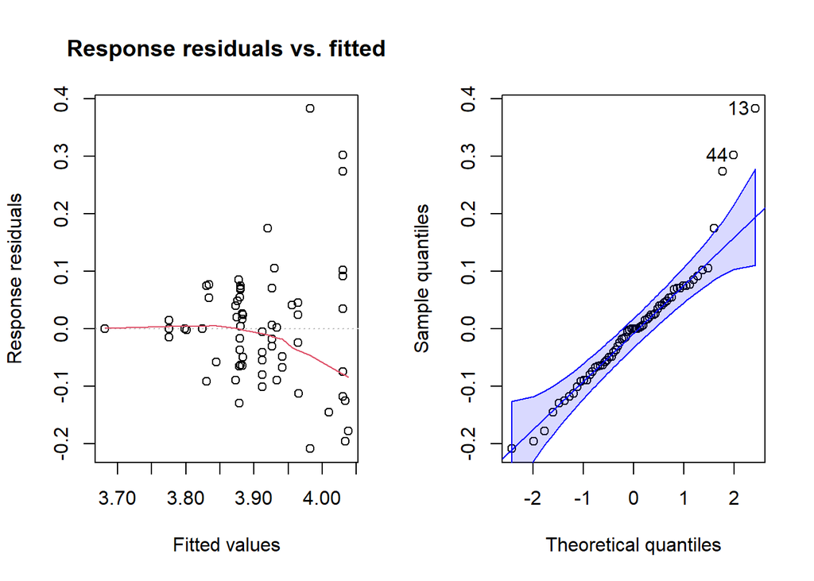

```r
#Model considering the effect of age and its interaction with the taxon on endogenous content
## Set levels, so that all species are compared to Cape buffalo. See also options("contrasts")
Data_Yes$Taxon_plots_common <- factor(Data_Yes$Taxon_plots_common,
                         levels = c("Cape buffalo", "Cape grysbok", "Common eland", "Grey rhebok", "Long-horned buffalo", "Reedbuck"))
LM_TP_Yes <- lm(log_rl ~ latest_chrono_age * Taxon_plots_common, data = Data_Yes)
RVAideMemoire::plotresid(LM_TP_Yes)
```

```r
summary(LM_TP_Yes)
```

```
##
## Call:
## lm(formula = log_rl ~ latest_chrono_age * Taxon_plots_common,
##     data = Data_Yes)
##
## Residuals:
##      Min       1Q   Median       3Q      Max
## -0.20886 -0.06418  0.00000  0.04845  0.38250
##
## Coefficients:
##                                                           Estimate Std. Error
## (Intercept)                                              4.069e+00  4.484e-02
## latest_chrono_age                                       -2.061e-05  7.751e-06
## Taxon_plots_commonCape grysbok                          -4.475e-02  7.466e-02
## Taxon_plots_commonCommon eland                           1.377e+00  1.090e+00
## Taxon_plots_commonGrey rhebok                           -1.820e-01  1.096e-01
## Taxon_plots_commonLong-horned buffalo                   -2.943e-01  2.941e-01
## Taxon_plots_commonReedbuck                              -2.752e-01  1.431e-01
## latest_chrono_age:Taxon_plots_commonCape grysbok         1.859e-07  1.224e-05
## latest_chrono_age:Taxon_plots_commonCommon eland        -1.443e-04  1.112e-04
## latest_chrono_age:Taxon_plots_commonGrey rhebok          1.936e-05  1.760e-05
## latest_chrono_age:Taxon_plots_commonLong-horned buffalo  2.064e-05  1.752e-05
## latest_chrono_age:Taxon_plots_commonReedbuck             2.123e-05  8.634e-06
##                                                         t value Pr(>|t|)
## (Intercept)                                              90.734   <2e-16 ***
## latest_chrono_age                                        -2.659   0.0103 *
## Taxon_plots_commonCape grysbok                           -0.599   0.5514
## Taxon_plots_commonCommon eland                            1.263   0.2120
## Taxon_plots_commonGrey rhebok                            -1.660   0.1028
## Taxon_plots_commonLong-horned buffalo                    -1.001   0.3215
## Taxon_plots_commonReedbuck                               -1.924   0.0598 .
## latest_chrono_age:Taxon_plots_commonCape grysbok          0.015   0.9879
## latest_chrono_age:Taxon_plots_commonCommon eland         -1.297   0.2001
## latest_chrono_age:Taxon_plots_commonGrey rhebok           1.100   0.2762
## latest_chrono_age:Taxon_plots_commonLong-horned buffalo   1.178   0.2440
## latest_chrono_age:Taxon_plots_commonReedbuck              2.458   0.0173 *
## ---
## Signif. codes:  0 '***' 0.001 '**' 0.01 '*' 0.05 '.' 0.1 ' ' 1
##
## Residual standard error: 0.1152 on 53 degrees of freedom
##   (4 observations deleted due to missingness)
## Multiple R-squared:  0.3468, Adjusted R-squared:  0.2112
## F-statistic: 2.558 on 11 and 53 DF,  p-value: 0.01122
```

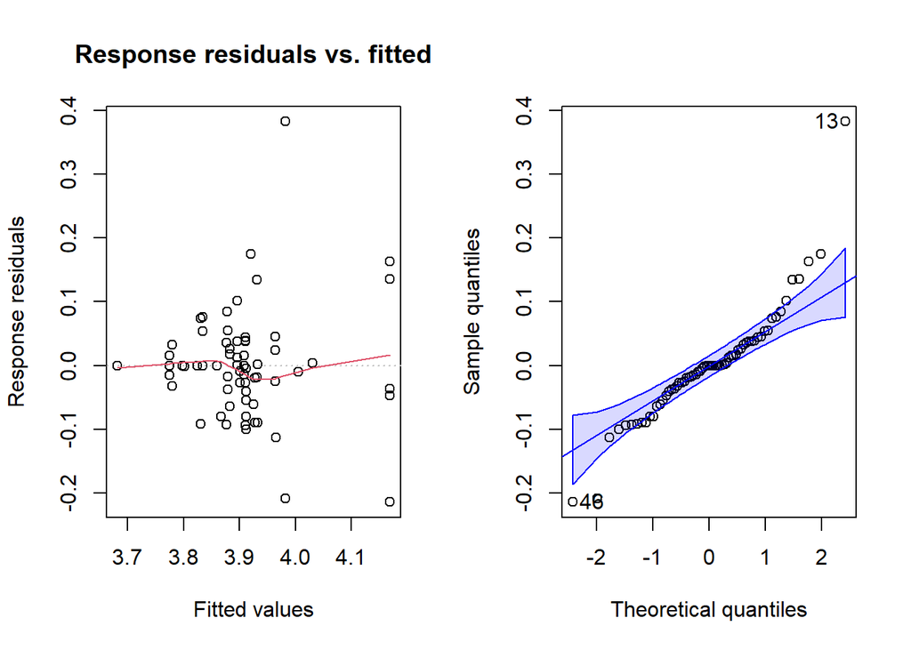

```r
#Model considering the effect of age and its interaction with site and taxon on endogenous content
LM_SS_TP_Yes <- lm(log_rl ~ latest_chrono_age * Site_short * Taxon_plots_common, data = Data_Yes)
RVAideMemoire::plotresid(LM_SS_TP_Yes)
```

```r
summary(LM_SS_TP_Yes)
```

```
##
## Call:
## lm(formula = log_rl ~ latest_chrono_age * Site_short * Taxon_plots_common,
##     data = Data_Yes)
##
## Residuals:
##      Min       1Q   Median       3Q      Max
## -0.21421 -0.03730  0.00000  0.03568  0.38250
##
## Coefficients: (53 not defined because of singularities)
##                                                                          Estimate
## (Intercept)                                                             3.946e+00
## latest_chrono_age                                                      -7.274e-06
## Site_shortDK1                                                          -1.324e+00
## Site_shortEBC                                                          -1.890e-01
## Site_shortKRM                                                           7.041e-01
## Site_shortBPA                                                          -1.865e-01
## Site_shortBNK1                                                         -5.391e-02
## Taxon_plots_commonCape grysbok                                          7.807e-02
## Taxon_plots_commonCommon eland                                          2.094e-03
## Taxon_plots_commonGrey rhebok                                          -3.208e-02
## Taxon_plots_commonLong-horned buffalo                                  -1.715e-01
## Taxon_plots_commonReedbuck                                              3.407e-02
## latest_chrono_age:Site_shortDK1                                         8.321e-04
## latest_chrono_age:Site_shortEBC                                                NA
## latest_chrono_age:Site_shortKRM                                        -3.100e-04
## latest_chrono_age:Site_shortBPA                                         7.890e-06
## latest_chrono_age:Site_shortBNK1                                        2.795e-05
## latest_chrono_age:Taxon_plots_commonCape grysbok                       -1.315e-05
## latest_chrono_age:Taxon_plots_commonCommon eland                               NA
## latest_chrono_age:Taxon_plots_commonGrey rhebok                         6.723e-06
## latest_chrono_age:Taxon_plots_commonLong-horned buffalo                 7.307e-06
## latest_chrono_age:Taxon_plots_commonReedbuck                                   NA
## Site_shortDK1:Taxon_plots_commonCape grysbok                                   NA
## Site_shortEBC:Taxon_plots_commonCape grysbok                                   NA
## Site_shortKRM:Taxon_plots_commonCape grysbok                                   NA
## Site_shortBPA:Taxon_plots_commonCape grysbok                                   NA
## Site_shortBNK1:Taxon_plots_commonCape grysbok                                  NA
## Site_shortDK1:Taxon_plots_commonCommon eland                                   NA
## Site_shortEBC:Taxon_plots_commonCommon eland                                   NA
```

[output cut: 327 more lines]

```
## latest_chrono_age:Site_shortKRM:Taxon_plots_commonLong-horned buffalo
## latest_chrono_age:Site_shortBPA:Taxon_plots_commonLong-horned buffalo
## latest_chrono_age:Site_shortBNK1:Taxon_plots_commonLong-horned buffalo
## latest_chrono_age:Site_shortDK1:Taxon_plots_commonReedbuck
## latest_chrono_age:Site_shortEBC:Taxon_plots_commonReedbuck
## latest_chrono_age:Site_shortKRM:Taxon_plots_commonReedbuck
## latest_chrono_age:Site_shortBPA:Taxon_plots_commonReedbuck
## latest_chrono_age:Site_shortBNK1:Taxon_plots_commonReedbuck
## ---
## Signif. codes:  0 '***' 0.001 '**' 0.01 '*' 0.05 '.' 0.1 ' ' 1
##
## Residual standard error: 0.1018 on 46 degrees of freedom
##   (4 observations deleted due to missingness)
## Multiple R-squared:  0.5577, Adjusted R-squared:  0.3846
## F-statistic: 3.222 on 18 and 46 DF,  p-value: 0.000701
```

```r
#Calculate the AIC/AIcc values for each model (AICc required for transformed response variable, as in our case)
AIC(LM_Yes, LM_SS_Yes, LM_MG_Yes, LM_SS_MG_Yes, LM_TP_Yes, LM_SS_TP_Yes)
```

```
##              df        AIC
## LM_Yes        3  -84.36382
## LM_SS_Yes    12 -107.88442
## LM_MG_Yes     5  -85.78642
## LM_SS_MG_Yes 14 -106.22892
## LM_TP_Yes    13  -83.74175
## LM_SS_TP_Yes 20  -95.08616
```

```r
purrr::map_dbl(list(LM_Yes = LM_Yes, LM_SS_Yes = LM_SS_Yes, LM_MG_Yes = LM_MG_Yes, LM_SS_MG_Yes = LM_SS_MG_Yes, LM_TP_Yes = LM_TP_Yes, LM_SS_TP_Yes = LM_SS_TP_Yes),
  performance::performance_aicc)
```

```
##       LM_Yes    LM_SS_Yes    LM_MG_Yes LM_SS_MG_Yes    LM_TP_Yes LM_SS_TP_Yes
##    -83.97037   -101.88442    -84.76947    -97.82892    -76.60449    -75.99526
```

**Note:** LM_SS_Yes (site) seem to fit OK and its AICc values is the lowest.

1. Independence (horizontal red line on left handside graph) looks ok
2. homoscedasticity (spread of data above and below 0 on left handside graph) looks good
3. and normality (data points inside blue region on right handside graph) looks good.

Will do remaining analyses on **LM_SS_Yes** (site)

```r
#Linear model with Site included

#ANOVA
car::Anova(LM_SS_Yes, type = "II")
```

```
## Note: model has aliased coefficients
##       sums of squares computed by model comparison
```

```
## Anova Table (Type II tests)
##
## Response: log_rl
##                               Sum Sq Df F value    Pr(>F)
## latest_chrono_age            0.01708  1  1.8436 0.1801760
## Site_short                   0.28084  5  6.0620 0.0001596 ***
## latest_chrono_age:Site_short 0.16654  4  4.4937 0.0033088 **
## Residuals                    0.50033 54
## ---
## Signif. codes:  0 '***' 0.001 '**' 0.01 '*' 0.05 '.' 0.1 ' ' 1
```

## 4.2. Summary of Age vs mean read length

The log-transformed data were normally distributed and could be analysed using a linear model. Various models were tested, taking into account additional factors like site of origin, species of origin, and material.

Overall, the best model was the lm model that took into account site as an experimental variable. The independence, homoscedasticity, and normality looked correct according to the resid plots.

**For this analysis the LM_SS model and ANOVA gave the following results**

1. Multiple R-squared: 0.5353
2. Adjusted R-squared: 0.4493
3. Age did not significantly impact mean read length, F = 1.8436, Df = 1, p > 0.05
4. Site significantly impacted mean read length, F = 6.0620, Df = 5, p < 0.001
5. latest_chrono_age:Site_short significantly impacted mean read length, F = 4.4937, Df = 4, p < 0.01

**Note:** The data are heavily skewed across sites, with 71% (46/65) of the samples coming from one site, NBC, and the other sites having <10 each. The two sites with a significant relationship with read length (EBC and KRM, p < 0.05) have 1 and 2 samples, respectively. Therefore, to see if age has an impact on read length within site, run NBC alone.

```r
table(Data_Yes$Site_short)
```

```
##
##  NBC  DK1  EBC  KRM  BPA BNK1
##   46    8    1    2    6    6
```

## 4.3. NBC: Age vs mean read length

```r
Data <- read_csv("Table S3 - paleomix nuclear & collagen.csv")

#Log transform the read length (in case needed)
Data$log_rl <- log(Data$noMicro_meanLengthxTarget)

# filter
Data_Yes_NBC <- Data %>%
  filter(species_identifiable == "Yes") %>%
  filter(Site_short == "NBC")
```

#### Create plot of age vs mean read length

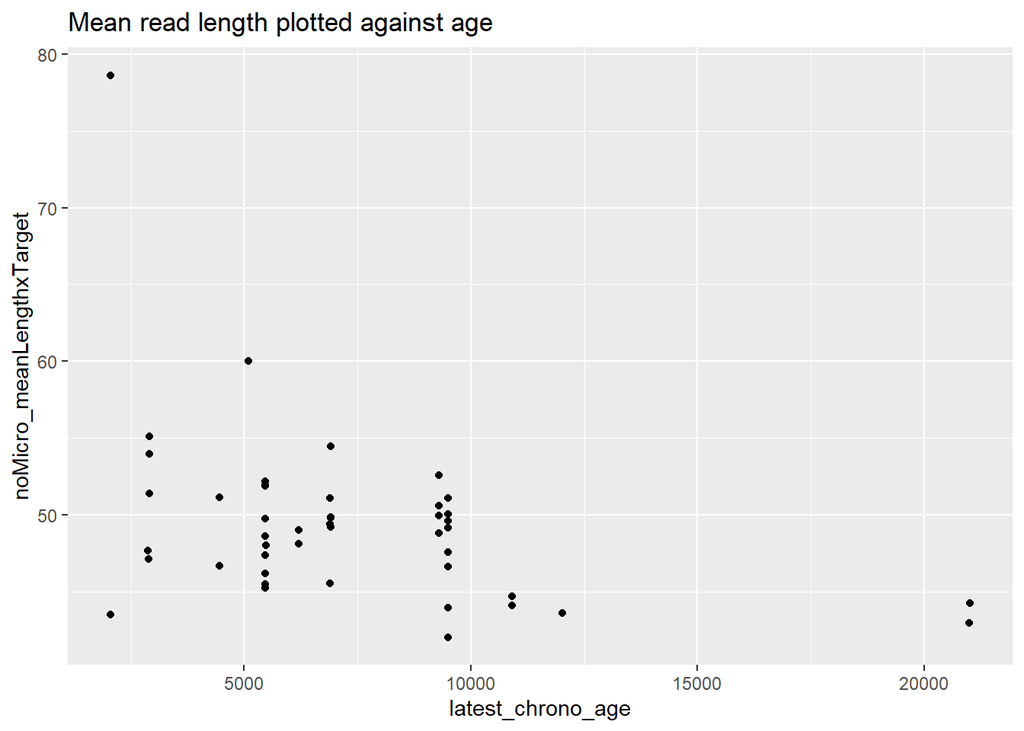

```r
Data_Yes_NBC %>%
  ggplot(aes(x = latest_chrono_age, y = noMicro_meanLengthxTarget)) +
  geom_jitter() +
  labs(title = "Mean read length plotted against age")
```

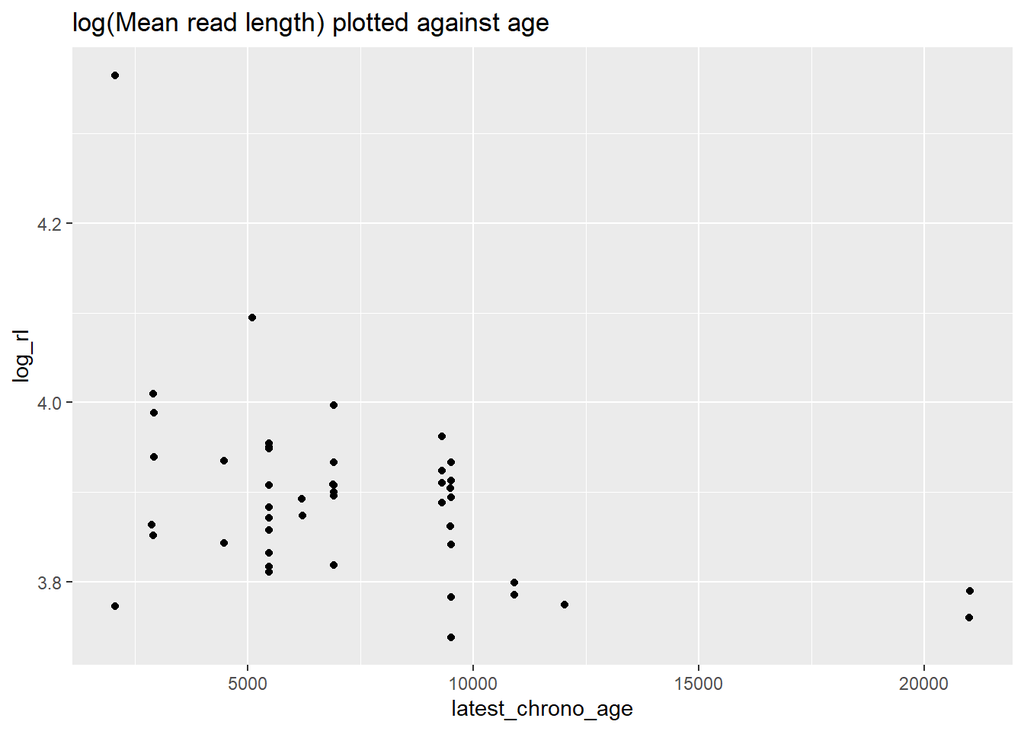

```r
Data_Yes_NBC %>%
  ggplot(aes(x = latest_chrono_age, y = log_rl)) +
  geom_jitter() +
  labs(title = "log(Mean read length) plotted against age")
```

#### Histograms

#### Figure out distribution of the data, based on endogenous content

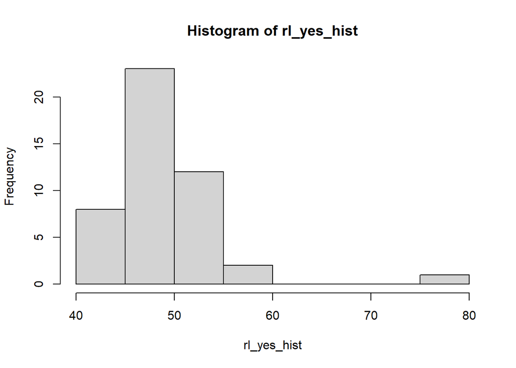

```r
#Filter based just on the endogenous content
rl_yes_hist <- Data_Yes_NBC$noMicro_meanLengthxTarget
log_rl_yes_hist <- Data_Yes_NBC$log_rl

#Generate the  histogram
hist(rl_yes_hist)
```

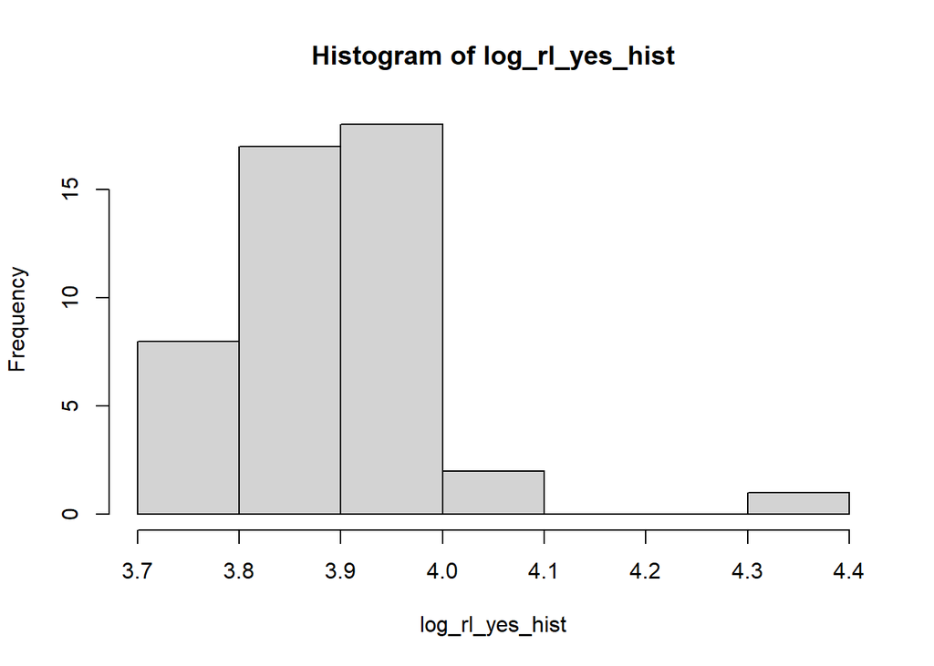

```r
hist(log_rl_yes_hist)
```

**Note:** The log transformed data looks more or less normally distributed, so test out linear models based on gaussian (=normal) distributions

#### Testing various models

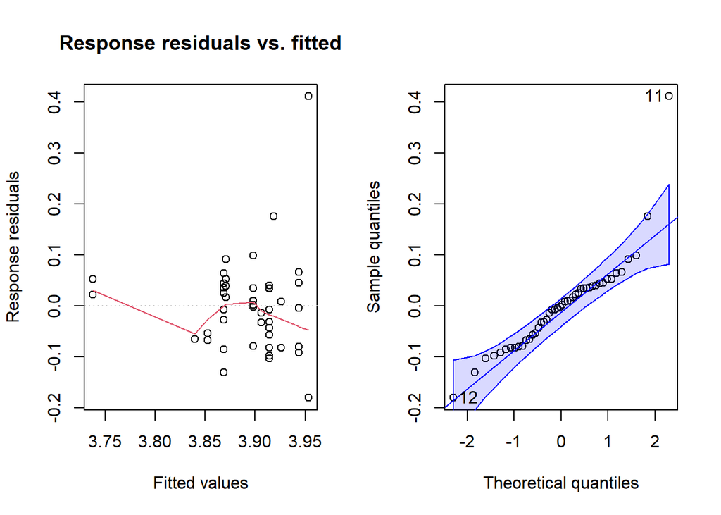

```r
#Use linear models for all, but test for the various potential factors

#Model only considering the effect of age on read length
LM_Yes <- lm(log_rl ~ latest_chrono_age, data = Data_Yes_NBC)
RVAideMemoire::plotresid(LM_Yes)
```

```r
summary(LM_Yes)
```

```
##
## Call:
## lm(formula = log_rl ~ latest_chrono_age, data = Data_Yes_NBC)
##
## Residuals:
##      Min       1Q   Median       3Q      Max
## -0.17999 -0.06297 -0.00003  0.03867  0.41137
##
## Coefficients:
##                     Estimate Std. Error t value Pr(>|t|)
## (Intercept)        3.977e+00  2.923e-02 136.069  < 2e-16 ***
## latest_chrono_age -1.137e-05  3.528e-06  -3.223  0.00239 **
## ---
## Signif. codes:  0 '***' 0.001 '**' 0.01 '*' 0.05 '.' 0.1 ' ' 1
##
## Residual standard error: 0.09256 on 44 degrees of freedom
## Multiple R-squared:  0.191,  Adjusted R-squared:  0.1726
## F-statistic: 10.39 on 1 and 44 DF,  p-value: 0.002392
```

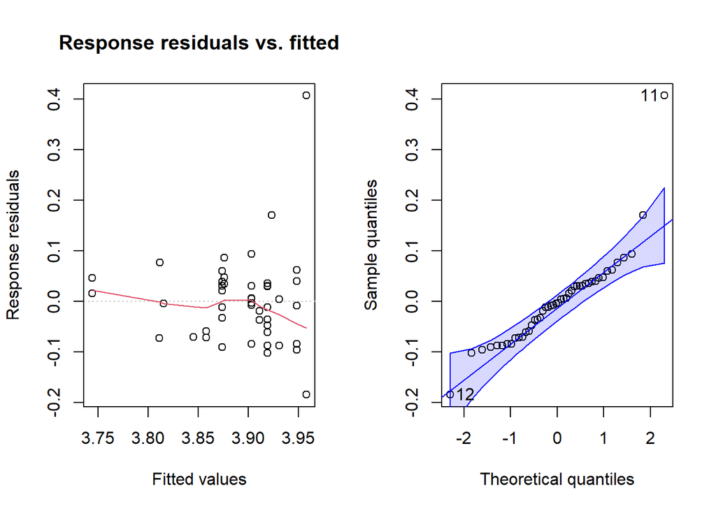

```r
#Model considering the effect of age and its interaction with material group on endogenous content
## Set levels, so that tooth is the reference. See also options("contrasts")
Data_Yes_NBC$material_group <- factor(Data_Yes_NBC$material_group,
                              levels = c("Tooth", "Bone"))
LM_MG_Yes <- lm(log_rl ~ latest_chrono_age * material_group, data = Data_Yes_NBC)
RVAideMemoire::plotresid(LM_MG_Yes)
```

```r
summary(LM_MG_Yes)
```

```
##
## Call:
## lm(formula = log_rl ~ latest_chrono_age * material_group, data = Data_Yes_NBC)
##
## Residuals:
##      Min       1Q   Median       3Q      Max
## -0.18448 -0.06081 -0.00336  0.03520  0.40688
##
## Coefficients:
##                                        Estimate Std. Error t value Pr(>|t|)
## (Intercept)                           3.981e+00  2.946e-02 135.129  < 2e-16 ***
## latest_chrono_age                    -1.127e-05  3.557e-06  -3.168  0.00286 **
## material_groupBone                   -1.601e-01  2.405e-01  -0.666  0.50929
## latest_chrono_age:material_groupBone  1.027e-05  2.898e-05   0.354  0.72493
## ---
## Signif. codes:  0 '***' 0.001 '**' 0.01 '*' 0.05 '.' 0.1 ' ' 1
##
## Residual standard error: 0.09249 on 42 degrees of freedom
## Multiple R-squared:  0.229,  Adjusted R-squared:  0.174
## F-statistic: 4.159 on 3 and 42 DF,  p-value: 0.01146
```

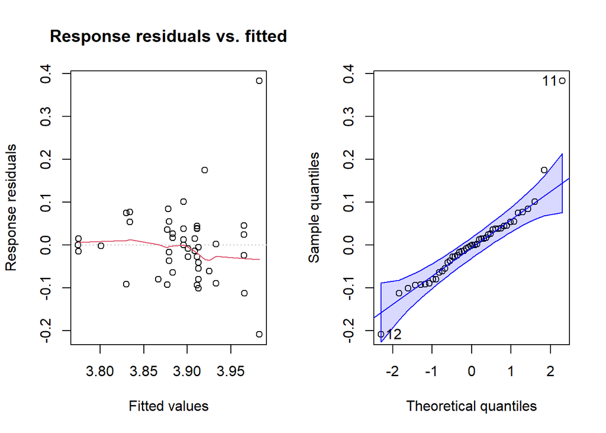

```r
#Model considering the effect of age and its interaction with the taxon on endogenous content
## Set levels, so that all species are compared to Cape grysbok (largest sample size at NBC). See also options("contrasts")
Data_Yes_NBC$Taxon_plots_common <- factor(Data_Yes_NBC$Taxon_plots_common,
                         levels = c("Cape grysbok", "Cape buffalo", "Common eland", "Grey rhebok", "Long-horned buffalo", "Reedbuck"))
LM_TP_Yes <- lm(log_rl ~ latest_chrono_age * Taxon_plots_common, data = Data_Yes_NBC)
RVAideMemoire::plotresid(LM_TP_Yes)
```

```r
summary(LM_TP_Yes)
```

```
##
## Call:
## lm(formula = log_rl ~ latest_chrono_age * Taxon_plots_common,
##     data = Data_Yes_NBC)
##
## Residuals:
##      Min       1Q   Median       3Q      Max
## -0.20886 -0.05122 -0.00092  0.03765  0.38250
##
## Coefficients: (1 not defined because of singularities)
##                                                           Estimate Std. Error
## (Intercept)                                              4.024e+00  5.062e-02
## latest_chrono_age                                       -2.042e-05  8.038e-06
## Taxon_plots_commonCape buffalo                          -7.807e-02  1.194e-01
## Taxon_plots_commonCommon eland                           4.895e-02  6.730e-02
## Taxon_plots_commonGrey rhebok                           -1.101e-01  1.505e-01
## Taxon_plots_commonLong-horned buffalo                   -2.495e-01  2.516e-01
## latest_chrono_age:Taxon_plots_commonCape buffalo         1.315e-05  1.610e-05
## latest_chrono_age:Taxon_plots_commonCommon eland                NA         NA
## latest_chrono_age:Taxon_plots_commonGrey rhebok          1.987e-05  2.226e-05
## latest_chrono_age:Taxon_plots_commonLong-horned buffalo  2.046e-05  1.556e-05
##                                                         t value Pr(>|t|)
## (Intercept)                                              79.501   <2e-16 ***
## latest_chrono_age                                        -2.541   0.0154 *
## Taxon_plots_commonCape buffalo                           -0.654   0.5174
## Taxon_plots_commonCommon eland                            0.727   0.4716
## Taxon_plots_commonGrey rhebok                            -0.732   0.4688
## Taxon_plots_commonLong-horned buffalo                    -0.992   0.3278
## latest_chrono_age:Taxon_plots_commonCape buffalo          0.817   0.4193
## latest_chrono_age:Taxon_plots_commonCommon eland             NA       NA
## latest_chrono_age:Taxon_plots_commonGrey rhebok           0.893   0.3779
## latest_chrono_age:Taxon_plots_commonLong-horned buffalo   1.315   0.1967
## ---
## Signif. codes:  0 '***' 0.001 '**' 0.01 '*' 0.05 '.' 0.1 ' ' 1
##
## Residual standard error: 0.0977 on 37 degrees of freedom
## Multiple R-squared:  0.2421, Adjusted R-squared:  0.07827
## F-statistic: 1.478 on 8 and 37 DF,  p-value: 0.1987
```

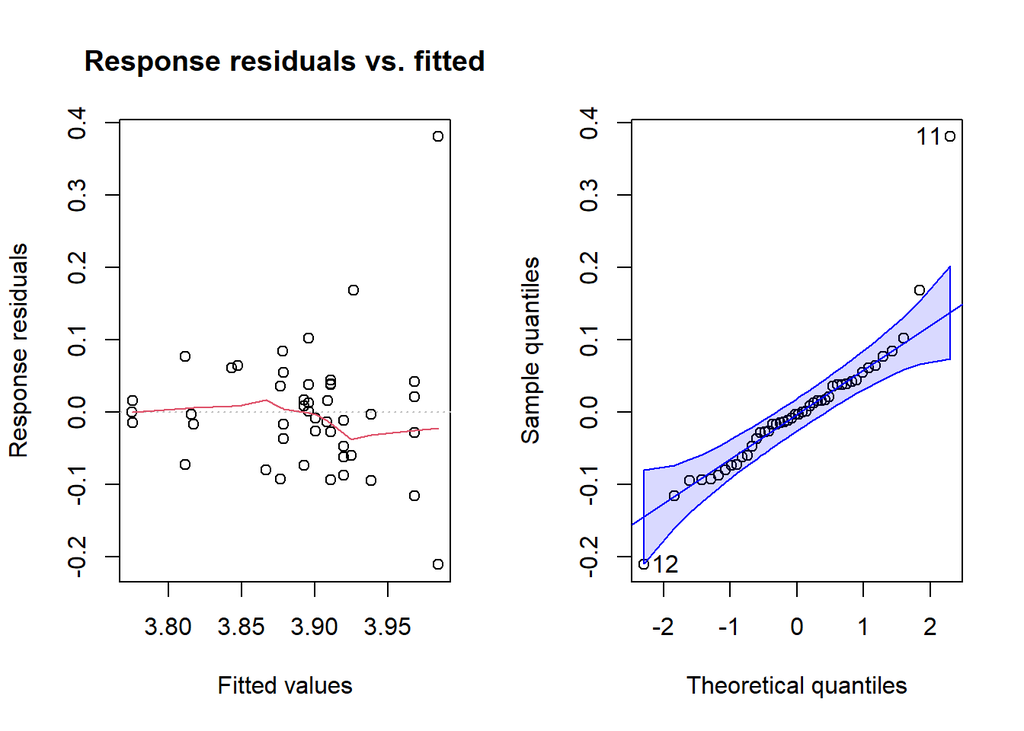

```r
#Model considering the effect of age and its interaction with site and taxon on endogenous content
LM_MG_TP_Yes <- lm(log_rl ~ latest_chrono_age * material_group * Taxon_plots_common, data = Data_Yes_NBC)
RVAideMemoire::plotresid(LM_MG_TP_Yes)
```

```r
summary(LM_MG_TP_Yes)
```

```
##
## Call:
## lm(formula = log_rl ~ latest_chrono_age * material_group * Taxon_plots_common,
##     data = Data_Yes_NBC)
##
## Residuals:
##      Min       1Q   Median       3Q      Max
## -0.21122 -0.04548 -0.00396  0.03765  0.38014
##
## Coefficients: (9 not defined because of singularities)
##                                                                              Estimate
## (Intercept)                                                                 4.023e+00
## latest_chrono_age                                                          -1.894e-05
## material_groupBone                                                         -2.025e-01
## Taxon_plots_commonCape buffalo                                             -7.738e-02
## Taxon_plots_commonCommon eland                                              3.553e-02
## Taxon_plots_commonGrey rhebok                                              -1.095e-01
## Taxon_plots_commonLong-horned buffalo                                      -2.488e-01
## latest_chrono_age:material_groupBone                                        1.794e-05
## latest_chrono_age:Taxon_plots_commonCape buffalo                            1.166e-05
## latest_chrono_age:Taxon_plots_commonCommon eland                                   NA
## latest_chrono_age:Taxon_plots_commonGrey rhebok                             1.839e-05
## latest_chrono_age:Taxon_plots_commonLong-horned buffalo                     1.897e-05
## material_groupBone:Taxon_plots_commonCape buffalo                                  NA
## material_groupBone:Taxon_plots_commonCommon eland                                  NA
## material_groupBone:Taxon_plots_commonGrey rhebok                                   NA
## material_groupBone:Taxon_plots_commonLong-horned buffalo                           NA
## latest_chrono_age:material_groupBone:Taxon_plots_commonCape buffalo                NA
## latest_chrono_age:material_groupBone:Taxon_plots_commonCommon eland                NA
## latest_chrono_age:material_groupBone:Taxon_plots_commonGrey rhebok                 NA
## latest_chrono_age:material_groupBone:Taxon_plots_commonLong-horned buffalo         NA
##                                                                            Std. Error
## (Intercept)                                                                 5.379e-02
## latest_chrono_age                                                           9.086e-06
## material_groupBone                                                          2.605e-01
## Taxon_plots_commonCape buffalo                                              1.219e-01
## Taxon_plots_commonCommon eland                                              7.195e-02
## Taxon_plots_commonGrey rhebok                                               1.531e-01
## Taxon_plots_commonLong-horned buffalo                                       2.550e-01
## latest_chrono_age:material_groupBone                                        3.203e-05
```

[output cut: 66 more lines]

```
## latest_chrono_age:Taxon_plots_commonLong-horned buffalo
## material_groupBone:Taxon_plots_commonCape buffalo
## material_groupBone:Taxon_plots_commonCommon eland
## material_groupBone:Taxon_plots_commonGrey rhebok
## material_groupBone:Taxon_plots_commonLong-horned buffalo
## latest_chrono_age:material_groupBone:Taxon_plots_commonCape buffalo
## latest_chrono_age:material_groupBone:Taxon_plots_commonCommon eland
## latest_chrono_age:material_groupBone:Taxon_plots_commonGrey rhebok
## latest_chrono_age:material_groupBone:Taxon_plots_commonLong-horned buffalo
## ---
## Signif. codes:  0 '***' 0.001 '**' 0.01 '*' 0.05 '.' 0.1 ' ' 1
##
## Residual standard error: 0.09879 on 35 degrees of freedom
## Multiple R-squared:  0.2669, Adjusted R-squared:  0.05747
## F-statistic: 1.274 on 10 and 35 DF,  p-value: 0.282
```

```r
#Calculate the AIC/AIcc values for each model (AICc required for transformed response variable, as in our case)
AIC(LM_Yes, LM_MG_Yes, LM_TP_Yes, LM_MG_TP_Yes)
```

```
##              df       AIC
## LM_Yes        3 -84.45030
## LM_MG_Yes     5 -82.66561
## LM_TP_Yes    10 -73.45448
## LM_MG_TP_Yes 12 -70.98454
```

```r
purrr::map_dbl(list(LM_Yes = LM_Yes, LM_MG_Yes = LM_MG_Yes, LM_TP_Yes = LM_TP_Yes, LM_MG_TP_Yes = LM_MG_TP_Yes),
  performance::performance_aicc)
```

```
##       LM_Yes    LM_MG_Yes    LM_TP_Yes LM_MG_TP_Yes
##    -83.87887    -81.16561    -67.16876    -61.52999
```

**Note:** LM_Yes (age) seem to fit OK and its AICc values is the lowest.

1. Independence (horizontal red line on left handside graph) looks ok
2. homoscedasticity (spread of data above and below 0 on left handside graph) looks good
3. and normality (data points inside blue region on right handside graph) looks good.

```r
#Linear model with Site included

#ANOVA
car::Anova(LM_Yes, type = "II")
```

```
## Anova Table (Type II tests)
##
## Response: log_rl
##                    Sum Sq Df F value   Pr(>F)
## latest_chrono_age 0.08899  1  10.387 0.002392 **
## Residuals         0.37699 44
## ---
## Signif. codes:  0 '***' 0.001 '**' 0.01 '*' 0.05 '.' 0.1 ' ' 1
```

## 4.4. Summary of Age vs mean read length

The log-transformed data were normally distributed and could be analysed using a linear model. Various models were tested, taking into account additional factors like species of origin, and material.

Overall, the best model was the lm model that only took into account age as an experimental variable. The independence, homoscedasticity, and normality looked correct according to the resid plots.

1. Multiple R-squared: 0.191
2. Adjusted R-squared: 0.1726
3. Age had a significant impact on mean read length, F = 10.387, Df = 1, p < 0.01